# Online Experiment

Alexander W. Cappelen, Sebastian Fest, Erik Ø. Sørensen, and Bertil Tungodden

# Reading in data.

```r
treatmentsv = c("Base (w)", "Forced Choice (w)", "Nominal Choice (w)",
                "Base (nw)", "Forced Choice (nw)", "Nominal Choice (nw)",
                "Forced Choice strong", "Forced Choice very strong")
treatmentsv_short = c("Base", "Forced Choice", "Nominal Choice")
df_k <- read_csv("bl_online.csv")  %>%
  mutate(treatment_org = factor(treatment, levels=treatmentsv),
         treatment = fct_recode(treatment_org,
                                "Forced Choice (w)" = "Forced Choice strong",
                                "Forced Choice (w)" = "Forced Choice very strong"),
         treatment_kantar = factor(treatment_kantar),
         treatmentgroup = factor(treatmentgroup, levels=treatmentsv_short),
         treatmentgroup8 = fct_recode(treatment,
                                      "Base" = "Base (w)",
                                      "Base" = "Base (nw)",
                                      "Nominal Choice" = "Nominal Choice (w)",
                                      "Nominal Choice" = "Nominal Choice (nw)",
                                      "Forced Choice" = "Forced Choice (w)",
                                      "Forced Choice" = "Forced Choice (nw)",
                                      "Forced Choice" = "Forced Choice strong",
                                      "Forced Choice" = "Forced Choice very strong"),
         gender = factor(gender),
         education = factor(education),
         indincome = factor(indincome),
         work_temp = fct_relevel(as.factor(workp), c("TRUE", "FALSE")),
         work = fct_recode(work_temp,
                           "Work" = "TRUE",
                           "No Work"= "FALSE"),
         inequality = abs(8 - 2*y)/8.0,
         zero_to_worst_off = (y %in% c(0,8)),
         university = (education %in% c("Universitet/hoyskole I", "Universitet/hoyskole II")),
         high_income = (indincome %in% c("1.000.000 kroner eller mer",
                                         "800.000 - 999.999 kroner",
                                         "700-000 - 799.999 kroner",
                                         "600.000 - 699.999 kroner",
                                         "500.000 - 599.999 kroner")),  # Median is within 400-499 group.
         female = (gender=="Kvinne"),
         choice = (treatmentgroup %in% c("Forced Choice", "Nominal Choice")),
         age_h = (age > median(age)),
         crt_h = (crt %in% c(2,3)),
         understanding2n = as.numeric(gsub("[^0-9]","", understanding2))) %>%
  filter(comp==1)
```

# Descriptive figures

## Histogram of transfers to the unlucky

First out is a histogram of the transfer to the unlucky participant. I make it for each of the three main treatments, with and without the work-distinction.

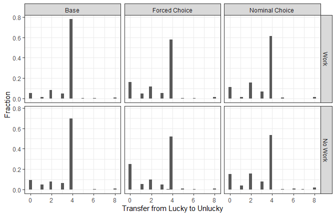

```r
df_k %>% ggplot(aes(x=y, y=1* (..count..)/tapply(..count..,..PANEL..,sum)[..PANEL..])) +
  geom_histogram() + facet_grid(work~treatmentgroup) + theme_bw() + ylab("Fraction") +
  xlab("Transfer from Lucky to Unlucky")
```

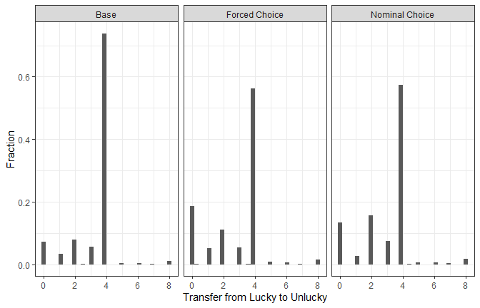

```r
ggsave(here("graphs", "histograms_kantar_wd.pdf"))
df_k %>% ggplot(aes(x=y, y=1* (..count..)/tapply(..count..,..PANEL..,sum)[..PANEL..])) +
  geom_histogram() + facet_grid(.~treatmentgroup) + theme_bw() + ylab("Fraction") +
  xlab("Transfer from Lucky to Unlucky")
```

```r
ggsave(here("graphs", "histograms_kantar.pdf"))
```

Now for a variant, without the weak forced choice (0.25), and only the work conditions:

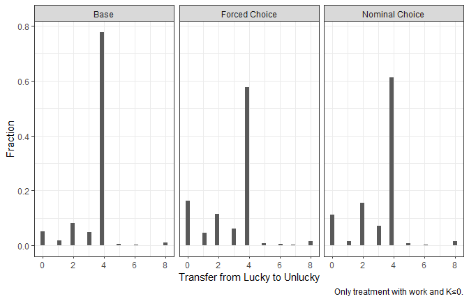

```r
df_k %>%  filter(workp==TRUE) %>%
  filter(!( treatment_org %in% c("Forced Choice (w)", "Forced Choice (nw)"))) %>%
  ggplot(aes(x=y, y=1* (..count..)/tapply(..count..,..PANEL..,sum)[..PANEL..])) +
  geom_histogram() + facet_grid(.~treatmentgroup) + theme_bw() +
  labs(y = "Fraction",
       x="Transfer from Lucky to Unlucky",
       caption="Only treatment with work and K\u22640.")
```

```r
ggsave(here("graphs", "histograms_kantar_strong.pdf"), device = cairo_pdf)
```

It is interesting to also look at how the histograms are similar also for all the different treatment variations, not only for the pooled groups:

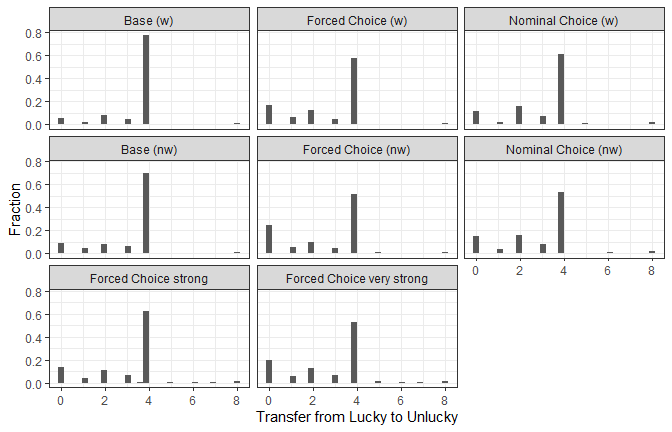

```r
df_k %>% ggplot(aes(x=y, y=1* (..count..)/tapply(..count..,..PANEL..,sum)[..PANEL..])) +
  geom_histogram() + facet_wrap(.~treatment_org) + theme_bw() + ylab("Fraction") +
  xlab("Transfer from Lucky to Unlucky")
```

```r
ggsave(here("graphs", "histograms_kantar_8.pdf"))
```

### The share that equalizes

```r
df_equal <- df_k %>% mutate(equal = (y==4))
df_equal %>%
  group_by(treatmentgroup) %>%
  summarize(share_equal=mean(equal)) %>%
  knitr::kable(digits=3)
```

| treatmentgroup | share_equal |
| --- | --- |
| Base | 0.738 |
| Forced Choice | 0.562 |
| Nominal Choice | 0.573 |

```r
ce <- df_equal %>%
  group_by(treatmentgroup) %>% summarize( yc = sum(y==4), n=n())
prop.test(ce$yc[ce$treatmentgroup %in% c("Base", "Nominal Choice") ],
          ce$n[ce$treatmentgroup %in% c("Base", "Nominal Choice") ])
```

```
#>
#>  2-sample test for equality of proportions with continuity correction
#>
#> data:  ce$yc[ce$treatmentgroup %in% c("Base", "Nominal Choice")] out of ce$n[ce$treatmentgroup %in% c("Base", "Nominal Choice")]
#> X-squared = 87.167, df = 1, p-value < 2.2e-16
#> alternative hypothesis: two.sided
#> 95 percent confidence interval:
#>  0.1307957 0.2004107
#> sample estimates:
#>    prop 1    prop 2
#> 0.7383242 0.5727209
```

```r
prop.test(ce$yc[ce$treatmentgroup %in% c("Base", "Forced Choice") ],
                    ce$n[ce$treatmentgroup %in% c("Base", "Forced Choice") ])
```

```
#>
#>  2-sample test for equality of proportions with continuity correction
#>
#> data:  ce$yc[ce$treatmentgroup %in% c("Base", "Forced Choice")] out of ce$n[ce$treatmentgroup %in% c("Base", "Forced Choice")]
#> X-squared = 126.14, df = 1, p-value < 2.2e-16
#> alternative hypothesis: two.sided
#> 95 percent confidence interval:
#>  0.1463265 0.2053218
#> sample estimates:
#>    prop 1    prop 2
#> 0.7383242 0.5625000
```

```r
prop.test(ce$yc[ce$treatmentgroup %in% c("Nominal Choice", "Forced Choice") ],
          ce$n[ce$treatmentgroup %in% c("Nominal Choice", "Forced Choice") ])
```

```
#>
#>  2-sample test for equality of proportions with continuity correction
#>
#> data:  ce$yc[ce$treatmentgroup %in% c("Nominal Choice", "Forced Choice")] out of ce$n[ce$treatmentgroup %in% c("Nominal Choice", "Forced Choice")]
#> X-squared = 0.36638, df = 1, p-value = 0.545
#> alternative hypothesis: two.sided
#> 95 percent confidence interval:
#>  -0.04211637  0.02167448
#> sample estimates:
#>    prop 1    prop 2
#> 0.5625000 0.5727209
```

### The share that gives nothing to unlucky

```r
df_0  <- df_k %>% mutate(nothing = (y==0))
df_0 %>%
  group_by(treatmentgroup) %>%
  summarize(share_equal=mean(nothing)) %>%
  knitr::kable(digits=3)
```

| treatmentgroup | share_equal |
| --- | --- |
| Base | 0.073 |
| Forced Choice | 0.186 |
| Nominal Choice | 0.134 |

```r
c0 <- df_0 %>%
  group_by(treatmentgroup) %>% summarize( y0= sum(y==0), n=n())
prop.test(c0$y0[c0$treatmentgroup %in% c("Base", "Nominal Choice") ],
          c0$n[c0$treatmentgroup %in% c("Base", "Nominal Choice") ])
```

```
#>
#>  2-sample test for equality of proportions with continuity correction
#>
#> data:  c0$y0[c0$treatmentgroup %in% c("Base", "Nominal Choice")] out of c0$n[c0$treatmentgroup %in% c("Base", "Nominal Choice")]
#> X-squared = 28.289, df = 1, p-value = 1.045e-07
#> alternative hypothesis: two.sided
#> 95 percent confidence interval:
#>  -0.08358136 -0.03803762
#> sample estimates:
#>    prop 1    prop 2
#> 0.0728022 0.1336117
```

```r
prop.test(c0$y0[c0$treatmentgroup %in% c("Base", "Forced Choice") ],
          c0$n[c0$treatmentgroup %in% c("Base", "Forced Choice") ])
```

```
#>
#>  2-sample test for equality of proportions with continuity correction
#>
#> data:  c0$y0[c0$treatmentgroup %in% c("Base", "Forced Choice")] out of c0$n[c0$treatmentgroup %in% c("Base", "Forced Choice")]
#> X-squared = 96.941, df = 1, p-value < 2.2e-16
#> alternative hypothesis: two.sided
#> 95 percent confidence interval:
#>  -0.13298830 -0.09291569
#> sample estimates:
#>    prop 1    prop 2
#> 0.0728022 0.1857542
```

```r
prop.test(c0$y0[c0$treatmentgroup %in% c("Nominal Choice", "Forced Choice") ],
          c0$n[c0$treatmentgroup %in% c("Nominal Choice", "Forced Choice") ])
```

```
#>
#>  2-sample test for equality of proportions with continuity correction
#>
#> data:  c0$y0[c0$treatmentgroup %in% c("Nominal Choice", "Forced Choice")] out of c0$n[c0$treatmentgroup %in% c("Nominal Choice", "Forced Choice")]
#> X-squared = 18.213, df = 1, p-value = 1.975e-05
#> alternative hypothesis: two.sided
#> 95 percent confidence interval:
#>  0.0289854 0.0752996
#> sample estimates:
#>    prop 1    prop 2
#> 0.1857542 0.1336117
```

## Mean inequality

The next descriptive figure is a bargraph showing the amount of inequality by treatment and work status.

First with work distinction:

```r
df_mean_ineq_nothing_kantar_wd <- df_k %>%
  dplyr::select(treatmentgroup, work, inequality, zero_to_worst_off) %>%
  gather(inequality, zero_to_worst_off, key="outcome", value="y") %>%
  group_by(treatmentgroup, work, outcome) %>%
  summarize(mean_y = mean(y, na.rm=TRUE), se_y = sd(y, na.rm=TRUE)/sqrt(n())) %>%
  mutate(outcome = fct_recode(outcome,
                              "Inequality" = "inequality",
                              "Nothing to worse off" = "zero_to_worst_off"))
df_mean_ineq_nothing_kantar_wd
```

```
#> # A tibble: 12 × 5
#> # Groups:   treatmentgroup, work [6]
#>    treatmentgroup work    outcome              mean_y    se_y
#>    <fct>          <fct>   <fct>                 <dbl>   <dbl>
#>  1 Base           Work    Inequality           0.134  0.0104
#>  2 Base           Work    Nothing to worse off 0.0644 0.00900
#>  3 Base           No Work Inequality           0.199  0.0129
#>  4 Base           No Work Nothing to worse off 0.104  0.0115
#>  5 Forced Choice  Work    Inequality           0.299  0.00859
#>  6 Forced Choice  Work    Nothing to worse off 0.179  0.00833
#>  7 Forced Choice  No Work Inequality           0.368  0.0158
#>  8 Forced Choice  No Work Nothing to worse off 0.259  0.0161
#>  9 Nominal Choice Work    Inequality           0.242  0.0133
#> 10 Nominal Choice Work    Nothing to worse off 0.129  0.0126
#> 11 Nominal Choice No Work Inequality           0.310  0.0143
#> 12 Nominal Choice No Work Nothing to worse off 0.173  0.0141
```

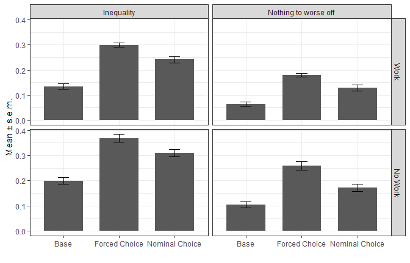

```r
df_mean_ineq_nothing_kantar_wd %>%
ggplot(aes(x=treatmentgroup, y=mean_y)) + geom_bar(stat="identity", width=0.7) +
  geom_errorbar(aes(ymax=mean_y+se_y, ymin=mean_y - se_y), width=0.2) +
  facet_grid(work ~ outcome) + xlab("") + ylab("Mean \u00B1 s.e.m.") +
  theme_bw()
```

```r
ggsave(here("graphs", "mean_ineq_nothing_kantar_wd.pdf"))
```

Similarly, without the work distinction for the main short paper.

```r
df_mean_ineq_nothing_kantar <- df_k %>%
  dplyr::select(treatmentgroup, inequality, zero_to_worst_off) %>%
  gather(inequality, zero_to_worst_off, key="outcome", value="y") %>%
  group_by(treatmentgroup, outcome) %>%
  summarize(mean_y = mean(y, na.rm=TRUE), se_y = sd(y, na.rm=TRUE)/sqrt(n())) %>%
  mutate(outcome = fct_recode(outcome,
                              "Inequality" = "inequality",
                              "Nothing to worse off" = "zero_to_worst_off"))
df_mean_ineq_nothing_kantar
```

```
#> # A tibble: 6 × 4
#> # Groups:   treatmentgroup [3]
#>   treatmentgroup outcome              mean_y    se_y
#>   <fct>          <fct>                 <dbl>   <dbl>
#> 1 Base           Inequality           0.166  0.00829
#> 2 Base           Nothing to worse off 0.0838 0.00726
#> 3 Forced Choice  Inequality           0.317  0.00759
#> 4 Forced Choice  Nothing to worse off 0.200  0.00748
#> 5 Nominal Choice Inequality           0.276  0.00980
#> 6 Nominal Choice Nothing to worse off 0.151  0.00945
```

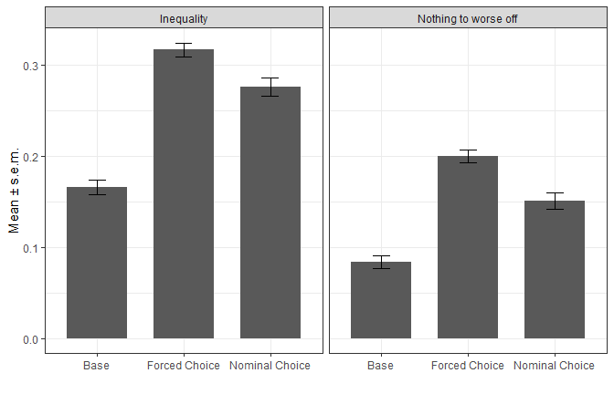

```r
df_mean_ineq_nothing_kantar %>%
ggplot(aes(x=treatmentgroup, y=mean_y)) + geom_bar(stat="identity", width=0.7) +
  geom_errorbar(aes(ymax=mean_y+se_y, ymin=mean_y - se_y), width=0.2) +
  facet_grid(. ~ outcome) + xlab("") + ylab("Mean \u00B1 s.e.m.") +
  theme_bw()
```

```r
ggsave(here("graphs", "mean_ineq_nothing_kantar.pdf"))
```

The same, but variant with Forced Choice ($K\leq0$) and only the work conditions:

```r
df_mean_ineq_nothing_kantar_wstrong <- df_k %>%
  filter(!( treatment_org %in% c("Forced Choice (w)", "Forced Choice (nw)"))) %>%
  filter(workp==TRUE) %>%
  dplyr::select(treatmentgroup, inequality, zero_to_worst_off) %>%
  gather(inequality, zero_to_worst_off, key="outcome", value="y") %>%
  group_by(treatmentgroup, outcome) %>%
  summarize(mean_y = mean(y, na.rm=TRUE), se_y = sd(y, na.rm=TRUE)/sqrt(n())) %>%
  mutate(outcome = fct_recode(outcome,
                              "Inequality" = "inequality",
                              "Nothing to worse off" = "zero_to_worst_off"))
df_mean_ineq_nothing_kantar_wstrong
```

```
#> # A tibble: 6 × 4
#> # Groups:   treatmentgroup [3]
#>   treatmentgroup outcome              mean_y    se_y
#>   <fct>          <fct>                 <dbl>   <dbl>
#> 1 Base           Inequality           0.134  0.0104
#> 2 Base           Nothing to worse off 0.0644 0.00900
#> 3 Forced Choice  Inequality           0.295  0.0104
#> 4 Forced Choice  Nothing to worse off 0.179  0.0102
#> 5 Nominal Choice Inequality           0.242  0.0133
#> 6 Nominal Choice Nothing to worse off 0.129  0.0126
```

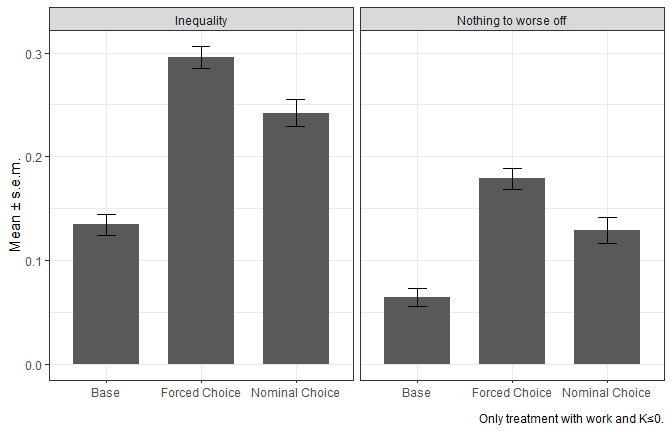

```r
df_mean_ineq_nothing_kantar_wstrong %>%
ggplot(aes(x=treatmentgroup, y=mean_y)) + geom_bar(stat="identity", width=0.7) +
  geom_errorbar(aes(ymax=mean_y+se_y, ymin=mean_y - se_y), width=0.2) +
  facet_grid(. ~ outcome) +
  labs(x = element_blank(),
       y = "Mean \u00B1 s.e.m.",
       caption="Only treatment with work and K\u22640.") +
  theme_bw()
```

```r
ggsave(here("graphs", "mean_ineq_nothing_kantar_wstrong.pdf"), device=cairo_pdf)
```

### Testing against Base treatment

For mean inequality:

```r
df_k %>% filter(treatmentgroup %in% c("Forced Choice", "Base")) %>%
  t.test(inequality ~ treatmentgroup, data=.)
```

```
#>
#>  Welch Two Sample t-test
#>
#> data:  inequality by treatmentgroup
#> t = -13.43, df = 3623.3, p-value < 2.2e-16
#> alternative hypothesis: true difference in means between group Base and group Forced Choice is not equal to 0
#> 95 percent confidence interval:
#>  -0.1729084 -0.1288535
#> sample estimates:
#>          mean in group Base mean in group Forced Choice
#>                   0.1661058                   0.3169867
```

```r
df_k %>% filter(treatmentgroup %in% c("Nominal Choice", "Base")) %>%
  t.test(inequality ~ treatmentgroup, data=.)
```

```
#>
#>  Welch Two Sample t-test
#>
#> data:  inequality by treatmentgroup
#> t = -8.5753, df = 2806.8, p-value < 2.2e-16
#> alternative hypothesis: true difference in means between group Base and group Nominal Choice is not equal to 0
#> 95 percent confidence interval:
#>  -0.13524719 -0.08490731
#> sample estimates:
#>           mean in group Base mean in group Nominal Choice
#>                    0.1661058                    0.2761830
```

### Testing Forced vs Nominal

First, for mean inequality:

```r
df_k %>% filter(treatmentgroup %in% c("Forced Choice", "Nominal Choice")) %>%
  t.test(inequality ~ treatmentgroup, data=.)
```

```
#>
#>  Welch Two Sample t-test
#>
#> data:  inequality by treatmentgroup
#> t = 3.2914, df = 3111.4, p-value = 0.001008
#> alternative hypothesis: true difference in means between group Forced Choice and group Nominal Choice is not equal to 0
#> 95 percent confidence interval:
#>  0.01649665 0.06511078
#> sample estimates:
#>  mean in group Forced Choice mean in group Nominal Choice
#>                    0.3169867                    0.2761830
```

Second, for giving nothing to the worst off

```r
nothingtw <- df_k %>%  group_by(treatmentgroup) %>%
  summarize( nothing = sum(inequality == 1), n=n())
prop.test(nothingtw$nothing[nothingtw$treatmentgroup %in% c("Forced Choice", "Nominal Choice") ],
          nothingtw$n[nothingtw$treatmentgroup %in% c("Forced Choice", "Nominal Choice") ])
```

```
#>
#>  2-sample test for equality of proportions with continuity correction
#>
#> data:  nothingtw$nothing[nothingtw$treatmentgroup %in% c("Forced Choice", "Nominal Choice")] out of nothingtw$n[nothingtw$treatmentgroup %in% c("Forced Choice", "Nominal Choice")]
#> X-squared = 15.035, df = 1, p-value = 0.0001055
#> alternative hypothesis: two.sided
#> 95 percent confidence interval:
#>  0.02492920 0.07319237
#> sample estimates:
#>    prop 1    prop 2
#> 0.2000698 0.1510090
```

```r
prop.test(nothingtw$nothing[nothingtw$treatmentgroup %in% c("Base", "Nominal Choice") ],
          nothingtw$n[nothingtw$treatmentgroup %in% c("Base", "Nominal Choice") ])
```

```
#>
#>  2-sample test for equality of proportions with continuity correction
#>
#> data:  nothingtw$nothing[nothingtw$treatmentgroup %in% c("Base", "Nominal Choice")] out of nothingtw$n[nothingtw$treatmentgroup %in% c("Base", "Nominal Choice")]
#> X-squared = 30.941, df = 1, p-value = 2.66e-08
#> alternative hypothesis: two.sided
#> 95 percent confidence interval:
#>  -0.09126026 -0.04317541
#> sample estimates:
#>     prop 1     prop 2
#> 0.08379121 0.15100905
```

```r
prop.test(nothingtw$nothing[nothingtw$treatmentgroup %in% c("Forced Choice", "Base") ],
          nothingtw$n[nothingtw$treatmentgroup %in% c("Forced Choice", "Base") ])
```

```
#>
#>  2-sample test for equality of proportions with continuity correction
#>
#> data:  nothingtw$nothing[nothingtw$treatmentgroup %in% c("Forced Choice", "Base")] out of nothingtw$n[nothingtw$treatmentgroup %in% c("Forced Choice", "Base")]
#> X-squared = 95.818, df = 1, p-value < 2.2e-16
#> alternative hypothesis: two.sided
#> 95 percent confidence interval:
#>  -0.1372223 -0.0953349
#> sample estimates:
#>     prop 1     prop 2
#> 0.08379121 0.20006983
```

# Robustness for the “forced” alternative

We did two variations of the “Forced Choice” treatment. One “strong” in which the alternative to the lottery was 0 cent with certainty, and one in which they actually had to pay 0.25 to avoid the lottery (I call it very-strong). Both these variants were with work. To look at the effect of this, I graph the level of inequality of the three forced choice treatments (with work) with the comparison to the base treatment (with work).

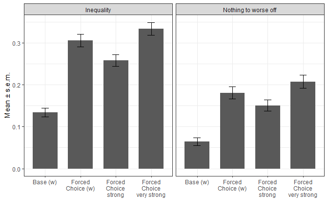

```r
df_k %>% filter(treatment_org %in% c("Base (w)",
                                 "Forced Choice (w)",
                                 "Forced Choice strong",
                                 "Forced Choice very strong")) %>%
  dplyr::select(treatment_org, inequality, zero_to_worst_off) %>%
  gather(inequality, zero_to_worst_off, key="outcome", value="y") %>%
  group_by(treatment_org, outcome) %>%
  summarize(mean_y = mean(y, na.rm=TRUE), se_y = sd(y, na.rm=TRUE)/sqrt(n())) %>%
  mutate(outcome = fct_recode(outcome,
                              "Inequality" = "inequality",
                              "Nothing to worse off" = "zero_to_worst_off")) %>%
  ggplot(aes(x=treatment_org, y=mean_y)) + geom_bar(stat="identity", width=0.7) +
    geom_errorbar(aes(ymax=mean_y+se_y, ymin=mean_y - se_y), width=0.2) +
    facet_wrap(~ outcome) + xlab("") + ylab("Mean \u00B1 s.e.m.") +
    theme_bw() + scale_x_discrete(labels=c("Base (w)",
                                           "Forced\nChoice (w)",
                                           "Forced\nChoice\nstrong",
                                           "Forced\nChoice\nvery strong"))
```

```r
ggsave(here("graphs", "mean_ineq_nothing_robust_kantar.pdf"))
```

Are the differences between the forced treatments significant? First a test of mean implemented inequality being the same in all forced (work) treatments:

```r
df_k %>% filter(treatment_org %in% c("Forced Choice (w)",
                                 "Forced Choice strong",
                                 "Forced Choice very strong")) %>%
  oneway.test( inequality ~ treatment_org, data=.)
```

```
#>
#>  One-way analysis of means (not assuming equal variances)
#>
#> data:  inequality and treatment_org
#> F = 6.9709, num df = 2.0, denom df = 1409.9, p-value = 0.0009715
```

Increases in implemented inequality compared to base treatment (for the forced choice variants).

```r
df_k %>% filter(treatment_org %in% c("Base (w)",
                                 "Forced Choice strong")) %>%
  t.test( inequality ~ treatment_org, data=.)
```

```
#>
#>  Welch Two Sample t-test
#>
#> data:  inequality by treatment_org
#> t = -7.0516, df = 1335.4, p-value = 2.83e-12
#> alternative hypothesis: true difference in means between group Base (w) and group Forced Choice strong is not equal to 0
#> 95 percent confidence interval:
#>  -0.15782165 -0.08912204
#> sample estimates:
#>             mean in group Base (w) mean in group Forced Choice strong
#>                          0.1343624                          0.2578343
```

```r
df_k %>% filter(treatment_org %in% c("Base (w)",
                                 "Forced Choice very strong")) %>%
  t.test( inequality ~ treatment_org, data=.)
```

```
#>
#>  Welch Two Sample t-test
#>
#> data:  inequality by treatment_org
#> t = -10.755, df = 1250.6, p-value < 2.2e-16
#> alternative hypothesis: true difference in means between group Base (w) and group Forced Choice very strong is not equal to 0
#> 95 percent confidence interval:
#>  -0.2359653 -0.1631619
#> sample estimates:
#>                  mean in group Base (w) mean in group Forced Choice very strong
#>                               0.1343624                               0.3339260
```

Now, the same test for the proportion implementing the nothing to the worst off:

```r
uz <- df_k %>% filter(treatment_org %in% c("Forced Choice (w)",
                                 "Forced Choice strong",
                                 "Forced Choice very strong")) %>%
  group_by(treatment_org) %>%
  summarize(tw0 = sum(inequality==1),  n=n())
prop.test(uz$tw0, uz$n)
```

```
#>
#>  3-sample test for equality of proportions without continuity correction
#>
#> data:  uz$tw0 out of uz$n
#> X-squared = 7.9248, df = 2, p-value = 0.01902
#> alternative hypothesis: two.sided
#> sample estimates:
#>    prop 1    prop 2    prop 3
#> 0.1809117 0.1504178 0.2076814
```

# Main regression tables

## Work and treatments

We want to pool the work and no-work treatments, so it is a question of interest whether there are interaction effects between the work requirement and treatments.

```r
w1 <- df_k %>% lm(inequality ~ treatmentgroup*workp , data=.)
w2 <- df_k %>% lm(inequality ~ treatmentgroup*workp + leftp + female + age_h + crt_h +
                             university + high_income, data=.)
w3 <- df_k %>% lm(inequality ~ treatmentgroup + workp + leftp + female + age_h + crt_h +
                             university + high_income, data=.)
w4 <- df_k %>% lm(zero_to_worst_off ~ treatmentgroup*workp , data=.)
w5 <- df_k %>% lm(zero_to_worst_off ~ treatmentgroup*workp + leftp + female + age_h + crt_h +
                             university + high_income, data=.)
w6 <- df_k %>% lm(zero_to_worst_off ~ treatmentgroup + workp + leftp + female + age_h + crt_h +
                             university + high_income, data=.)
```

We want to test the joint significance of the interactions

```r
w1t <- glht(w1, linfct= c("`treatmentgroupForced Choice:workpTRUE` = 0",
                          "`treatmentgroupNominal Choice:workpTRUE` = 0"),
             vcov = cluster.vcov(w1, cluster=1:nrow(df_k)))
w2t <- glht(w2, linfct= c("`treatmentgroupForced Choice:workpTRUE` = 0",
                          "`treatmentgroupNominal Choice:workpTRUE` = 0"),
             vcov = cluster.vcov(w2, cluster=1:nrow(df_k)))
w4t <- glht(w4, linfct= c("`treatmentgroupForced Choice:workpTRUE` = 0",
                          "`treatmentgroupNominal Choice:workpTRUE` = 0"),
             vcov = cluster.vcov(w4, cluster=1:nrow(df_k)))
w5t <- glht(w5, linfct= c("`treatmentgroupForced Choice:workpTRUE` = 0",
                          "`treatmentgroupNominal Choice:workpTRUE` = 0"),
             vcov = cluster.vcov(w5, cluster=1:nrow(df_k)))

wrow <- c("Joint p-value on work-interactions:",
          sprintf("%4.3f", summary(w1t)$test$pvalue[1]),
          sprintf("%4.3f", summary(w2t)$test$pvalue[1]), "",
          sprintf("%4.3f", summary(w4t)$test$pvalue[1]),
          sprintf("%4.3f", summary(w5t)$test$pvalue[1]), "")
```

Now for table output:

```r
stargazer(w1, w2, w3, w4, w5, w6,
          se = list(sqrt(diag(cluster.vcov(w1, cluster=1:nrow(df_k)))),
                    sqrt(diag(cluster.vcov(w2, cluster=1:nrow(df_k)))),
                    sqrt(diag(cluster.vcov(w3, cluster=1:nrow(df_k)))),
                    sqrt(diag(cluster.vcov(w4, cluster=1:nrow(df_k)))),
                    sqrt(diag(cluster.vcov(w5, cluster=1:nrow(df_k)))),
                    sqrt(diag(cluster.vcov(w6, cluster=1:nrow(df_k))))),
        add.lines=list(wrow),
        type="text", style="aer", df=FALSE, keep.stat=c("rsq","n"),
        p.auto=TRUE,
        order=c("treatmentgroup*", "workp"),
        star.char=c("", "",""), notes="", notes.append=FALSE, report="vcsp", header=FALSE)
```

```
#>
#> ===============================================================================================
#>                                              inequality                 zero_to_worst_off
#>                                        (1)       (2)       (3)       (4)       (5)       (6)
#> -----------------------------------------------------------------------------------------------
#> treatmentgroupForced Choice           0.169     0.164     0.162     0.155     0.152     0.127
#>                                      (0.020)   (0.020)   (0.011)   (0.020)   (0.019)   (0.011)
#>                                     p = 0.000 p = 0.000 p = 0.000 p = 0.000 p = 0.000 p = 0.000
#>
#> treatmentgroupNominal Choice          0.110     0.114     0.108     0.069     0.071     0.066
#>                                      (0.019)   (0.019)   (0.013)   (0.018)   (0.018)   (0.012)
#>                                     p = 0.000 p = 0.000 p = 0.000 p = 0.001 p = 0.000 p = 0.000
#>
#> treatmentgroupForced Choice:workp    -0.004    -0.004              -0.040    -0.040
#>                                      (0.024)   (0.024)             (0.023)   (0.023)
#>                                     p = 0.863 p = 0.864           p = 0.086 p = 0.079
#>
#> treatmentgroupNominal Choice:workp   -0.003    -0.011              -0.004    -0.010
#>                                      (0.026)   (0.025)             (0.024)   (0.024)
#>                                     p = 0.919 p = 0.648           p = 0.868 p = 0.687
#>
#> workp                                -0.065    -0.064    -0.069    -0.040    -0.039    -0.059
#>                                      (0.017)   (0.016)   (0.010)   (0.015)   (0.014)   (0.010)
#>                                     p = 0.000 p = 0.000 p = 0.000 p = 0.007 p = 0.008 p = 0.000
#>
#> leftp                                          -0.064    -0.064              -0.047    -0.047
#>                                                (0.011)   (0.011)             (0.011)   (0.011)
#>                                               p = 0.000 p = 0.000           p = 0.000 p = 0.000
#>
#> female                                         -0.084    -0.084              -0.044    -0.044
#>                                                (0.010)   (0.010)             (0.010)   (0.010)
#>                                               p = 0.000 p = 0.000           p = 0.000 p = 0.000
#>
#> age_h                                          -0.078    -0.078              -0.057    -0.057
#>                                                (0.010)   (0.010)             (0.009)   (0.009)
#>                                               p = 0.000 p = 0.000           p = 0.000 p = 0.000
#>
#> crt_h                                           0.059     0.059               0.052     0.051
#>                                                (0.010)   (0.010)             (0.010)   (0.010)
#>                                               p = 0.000 p = 0.000           p = 0.000 p = 0.000
#>
#> university                                      0.015     0.016               0.021     0.021
#>                                                (0.010)   (0.010)             (0.010)   (0.010)
#>                                               p = 0.125 p = 0.123           p = 0.033 p = 0.033
#>
#> high_income                                     0.050     0.050               0.049     0.049
#>                                                (0.011)   (0.011)             (0.011)   (0.011)
#>                                               p = 0.000 p = 0.000           p = 0.000 p = 0.000
#>
#> Constant                              0.199     0.266     0.269     0.104     0.131     0.141
#>                                      (0.013)   (0.018)   (0.016)   (0.011)   (0.017)   (0.015)
#>                                     p = 0.000 p = 0.000 p = 0.000 p = 0.000 p = 0.000 p = 0.000
#>
#> Joint p-value on work-interactions:   0.979     0.979               0.157     0.144
#> Observations                          5,757     5,757     5,757     5,757     5,757     5,757
#> R2                                    0.033     0.084     0.084     0.023     0.055     0.054
#> -----------------------------------------------------------------------------------------------
#> Notes:
```

From this we conclude that we can pool the work/no-work treatments, and simplify with only a dummy for work condition as a level shifter.

## The role of choice

The first regression table just regress inequality (and zero to the worst off) on treatment indicators and demographics (Table 1 in submitted version).

We want the main table for the paper to pool work/no-work completely.

```r
t1ineq_1 <-  df_k %>% lm(inequality ~ treatmentgroup + workp , data = . )
t1ineq_2 <-  df_k %>% lm(inequality ~ treatmentgroup + workp  +
                             leftp + female + age_h + crt_h, data=.)
t1ineq_3 <-  df_k %>% lm(inequality ~ treatmentgroup  + workp +
                             leftp + female + age_h + crt_h +
                             university + high_income, data=.)

t1noth_1 <-  df_k %>% lm( zero_to_worst_off ~ treatmentgroup + workp, data = . )
t1noth_2  <- df_k %>% lm( zero_to_worst_off ~ treatmentgroup + workp  +
                              leftp + female + age_h + crt_h, data=.)
t1noth_3  <- df_k %>% lm( zero_to_worst_off ~ treatmentgroup  + workp +
                              leftp + female + age_h + crt_h +
                              university + high_income, data=.)
```

Now, outputting these regressions to a table.

```r
stargazer(t1ineq_1, t1ineq_2, t1ineq_3, t1noth_1, t1noth_2, t1noth_3,
          se = list(sqrt(diag(cluster.vcov(t1ineq_1, cluster=1:nrow(df_k)))),
                    sqrt(diag(cluster.vcov(t1ineq_2, cluster=1:nrow(df_k)))),
                    sqrt(diag(cluster.vcov(t1ineq_3, cluster=1:nrow(df_k)))),
                    sqrt(diag(cluster.vcov(t1noth_1, cluster=1:nrow(df_k)))),
                    sqrt(diag(cluster.vcov(t1noth_2, cluster=1:nrow(df_k)))),
                    sqrt(diag(cluster.vcov(t1noth_3, cluster=1:nrow(df_k))))),
         type="text", style="aer", df=FALSE, keep.stat=c("rsq","n"),
        p.auto=TRUE,
        star.char=c("", "",""), notes="", notes.append=FALSE, report="vcsp", header=FALSE)
```

```
#>
#> ========================================================================================
#>                                       inequality                 zero_to_worst_off
#>                                 (1)       (2)       (3)       (4)       (5)       (6)
#> ----------------------------------------------------------------------------------------
#> treatmentgroupForced Choice    0.166     0.162     0.162     0.130     0.127     0.127
#>                               (0.011)   (0.011)   (0.011)   (0.011)   (0.011)   (0.011)
#>                              p = 0.000 p = 0.000 p = 0.000 p = 0.000 p = 0.000 p = 0.000
#>
#> treatmentgroupNominal Choice   0.109     0.108     0.108     0.066     0.066     0.066
#>                               (0.013)   (0.013)   (0.013)   (0.012)   (0.012)   (0.012)
#>                              p = 0.000 p = 0.000 p = 0.000 p = 0.000 p = 0.000 p = 0.000
#>
#> workp                         -0.068    -0.069    -0.069    -0.058    -0.059    -0.059
#>                               (0.011)   (0.010)   (0.010)   (0.010)   (0.010)   (0.010)
#>                              p = 0.000 p = 0.000 p = 0.000 p = 0.000 p = 0.000 p = 0.000
#>
#> leftp                                   -0.067    -0.064              -0.050    -0.047
#>                                         (0.011)   (0.011)             (0.011)   (0.011)
#>                                        p = 0.000 p = 0.000           p = 0.000 p = 0.000
#>
#> female                                  -0.094    -0.084              -0.054    -0.044
#>                                         (0.010)   (0.010)             (0.010)   (0.010)
#>                                        p = 0.000 p = 0.000           p = 0.000 p = 0.000
#>
#> age_h                                   -0.077    -0.078              -0.056    -0.057
#>                                         (0.010)   (0.010)             (0.009)   (0.009)
#>                                        p = 0.000 p = 0.000           p = 0.000 p = 0.000
#>
#> crt_h                                    0.066     0.059               0.059     0.051
#>                                         (0.010)   (0.010)             (0.010)   (0.010)
#>                                        p = 0.000 p = 0.000           p = 0.000 p = 0.000
#>
#> university                                         0.016                         0.021
#>                                                   (0.010)                       (0.010)
#>                                                  p = 0.123                     p = 0.033
#>
#> high_income                                        0.050                         0.049
#>                                                   (0.011)                       (0.011)
#>                                                  p = 0.000                     p = 0.000
#>
#> Constant                       0.201     0.299     0.269     0.113     0.174     0.141
#>                               (0.010)   (0.015)   (0.016)   (0.009)   (0.015)   (0.015)
#>                              p = 0.000 p = 0.000 p = 0.000 p = 0.000 p = 0.000 p = 0.000
#>
#> Observations                   5,757     5,757     5,757     5,757     5,757     5,757
#> R2                             0.033     0.080     0.084     0.023     0.049     0.054
#> ----------------------------------------------------------------------------------------
#> Notes:
```

And to disk:

```r
df_kwK <- df_k %>% filter(treatment_org %in% c("Base (w)",
                                               "Nominal Choice (w)",
                                               "Forced Choice (w)",
                                               "Forced Choice strong",
                                               "Forced Choice very strong"))
t1ineq_1v <-  df_kwK %>% lm(inequality ~ treatmentgroup  , data = . )
t1ineq_2v <-  df_kwK %>% lm(inequality ~ treatmentgroup   +
                             leftp + female + age_h + crt_h, data=.)
t1ineq_3v <-  df_kwK %>% lm(inequality ~ treatmentgroup  +
                             leftp + female + age_h + crt_h +
                             university + high_income, data=.)

t1noth_1v <-  df_kwK %>% lm( zero_to_worst_off ~ treatmentgroup , data = . )
t1noth_2v  <- df_kwK %>% lm( zero_to_worst_off ~ treatmentgroup   +
                              leftp + female + age_h + crt_h, data=.)
t1noth_3v  <- df_kwK %>% lm( zero_to_worst_off ~ treatmentgroup  +
                              leftp + female + age_h + crt_h +
                              university + high_income, data=.)
```

Now, outputting these regressions to a table.

```r
stargazer(t1ineq_1v, t1ineq_2v, t1ineq_3v, t1noth_1v, t1noth_2v, t1noth_3v,
          se = list(sqrt(diag(cluster.vcov(t1ineq_1v, cluster=1:nrow(df_kwK)))),
                    sqrt(diag(cluster.vcov(t1ineq_2v, cluster=1:nrow(df_kwK)))),
                    sqrt(diag(cluster.vcov(t1ineq_3v, cluster=1:nrow(df_kwK)))),
                    sqrt(diag(cluster.vcov(t1noth_1v, cluster=1:nrow(df_kwK)))),
                    sqrt(diag(cluster.vcov(t1noth_2v, cluster=1:nrow(df_kwK)))),
                    sqrt(diag(cluster.vcov(t1noth_3v, cluster=1:nrow(df_kwK))))),
         type="text", style="aer", df=FALSE, keep.stat=c("rsq","n"),
        p.auto=TRUE,
        star.char=c("", "",""), notes="", notes.append=FALSE, report="vcsp", header=FALSE,
        out = here("tables", "main_onlinev.tex"))
```

```
#>
#> ========================================================================================
#>                                       inequality                 zero_to_worst_off
#>                                 (1)       (2)       (3)       (4)       (5)       (6)
#> ----------------------------------------------------------------------------------------
#> treatmentgroupForced Choice    0.165     0.160     0.160     0.115     0.112     0.112
#>                               (0.014)   (0.013)   (0.013)   (0.012)   (0.012)   (0.012)
#>                              p = 0.000 p = 0.000 p = 0.000 p = 0.000 p = 0.000 p = 0.000
#>
#> treatmentgroupNominal Choice   0.108     0.102     0.102     0.065     0.061     0.061
#>                               (0.017)   (0.017)   (0.017)   (0.015)   (0.015)   (0.015)
#>                              p = 0.000 p = 0.000 p = 0.000 p = 0.000 p = 0.000 p = 0.000
#>
#> leftp                                   -0.062    -0.058              -0.049    -0.045
#>                                         (0.013)   (0.013)             (0.013)   (0.013)
#>                                        p = 0.000 p = 0.000           p = 0.001 p = 0.001
#>
#> female                                  -0.093    -0.081              -0.045    -0.033
#>                                         (0.012)   (0.013)             (0.012)   (0.012)
#>                                        p = 0.000 p = 0.000           p = 0.001 p = 0.005
#>
#> age_h                                   -0.074    -0.075              -0.050    -0.050
#>                                         (0.012)   (0.012)             (0.011)   (0.011)
#>                                        p = 0.000 p = 0.000           p = 0.000 p = 0.000
#>
#> crt_h                                    0.062     0.057               0.053     0.048
#>                                         (0.012)   (0.012)             (0.012)   (0.012)
#>                                        p = 0.000 p = 0.000           p = 0.000 p = 0.000
#>
#> university                                         0.009                         0.010
#>                                                   (0.013)                       (0.012)
#>                                                  p = 0.471                     p = 0.387
#>
#> high_income                                        0.059                         0.056
#>                                                   (0.014)                       (0.014)
#>                                                  p = 0.000                     p = 0.000
#>
#> Constant                       0.134     0.229     0.197     0.064     0.119     0.088
#>                               (0.010)   (0.017)   (0.018)   (0.009)   (0.016)   (0.017)
#>                              p = 0.000 p = 0.000 p = 0.000 p = 0.000 p = 0.000 p = 0.000
#>
#> Observations                   3,581     3,581     3,581     3,581     3,581     3,581
#> R2                             0.030     0.074     0.080     0.017     0.038     0.045
#> ----------------------------------------------------------------------------------------
#> Notes:
```

## Heterogeneity in effects

In the new heterogeneity table, we treat the background variables symmetrically.

### Heterogeneity in effects on inequality

```r
h1_1 <- df_k %>% lm(inequality ~ choice  + workp + leftp  + crt_h + female + age_h + university + high_income,
                      data=. )
h1_2 <- df_k %>% lm(inequality ~ choice  + workp + leftp  + crt_h + female + age_h + university + high_income +
                        choice*leftp, data=. )
h1_3 <- df_k %>% lm(inequality ~ choice + workp + leftp  + crt_h + female + age_h + university + high_income +
                        choice*female, data=. )
h1_4 <- df_k %>% lm(inequality ~ choice + workp + leftp + crt_h + female + age_h + university + high_income +
                        choice*age_h, data=. )
h1_5 <- df_k %>% lm(inequality ~ choice + workp + leftp  + crt_h + female + age_h + university + high_income +
                        choice*crt_h, data=. )
h1_6 <- df_k %>% lm(inequality ~ choice + workp + leftp  + crt_h + female + age_h + university + high_income +
                        choice*university, data=. )
h1_7 <- df_k %>% lm(inequality ~ choice + workp + leftp  + crt_h + female + age_h + university + high_income +
                        choice*high_income, data=. )
h1_8 <- df_k %>% lm(inequality ~ choice + workp + leftp  + crt_h + female + age_h + university + high_income +
                        choice*leftp + choice*female + choice*age_h + choice*crt_h + choice*university +
                        choice*high_income, data=. )
```

Want to include linear combinations for the columns 2-7:

```r
ch2 <- glht(h1_2, linfct="choiceTRUE + choiceTRUE:leftpTRUE = 0",
             vcov = cluster.vcov(h1_2, cluster=1:nrow(df_k)))
ch3 <- glht(h1_3, linfct="choiceTRUE + choiceTRUE:femaleTRUE = 0",
             vcov = cluster.vcov(h1_3, cluster=1:nrow(df_k)))
ch4 <- glht(h1_4, linfct="choiceTRUE + choiceTRUE:age_hTRUE = 0",
             vcov = cluster.vcov(h1_4, cluster=1:nrow(df_k)))
ch5 <- glht(h1_5, linfct="choiceTRUE + choiceTRUE:crt_hTRUE = 0",
             vcov = cluster.vcov(h1_5, cluster=1:nrow(df_k)))
ch6 <- glht(h1_6, linfct="choiceTRUE + choiceTRUE:universityTRUE = 0",
             vcov = cluster.vcov(h1_6, cluster=1:nrow(df_k)))
ch7 <- glht(h1_7, linfct="choiceTRUE + choiceTRUE:high_incomeTRUE = 0",
             vcov = cluster.vcov(h1_7, cluster=1:nrow(df_k)))
sh1 <- c("Linear combination"," ",
        sprintf("%4.3f", summary(ch2)$test$coefficients[1]),
        sprintf("%4.3f", summary(ch3)$test$coefficients[1]),
        sprintf("%4.3f", summary(ch4)$test$coefficients[1]),
        sprintf("%4.3f", summary(ch5)$test$coefficients[1]),
        sprintf("%4.3f", summary(ch6)$test$coefficients[1]),
        sprintf("%4.3f", summary(ch7)$test$coefficients[1]),
        "")
sh2 <- c("","",
        sprintf("(%4.3f)", summary(ch2)$test$sigma[1]),
        sprintf("(%4.3f)", summary(ch3)$test$sigma[1]),
        sprintf("(%4.3f)", summary(ch4)$test$sigma[1]),
        sprintf("(%4.3f)", summary(ch5)$test$sigma[1]),
        sprintf("(%4.3f)", summary(ch6)$test$sigma[1]),
        sprintf("(%4.3f)", summary(ch7)$test$sigma[1]),
        "")
sh3 <- c("", "",
        sprintf("p=%4.3f", summary(ch2)$test$pvalues[1]),
        sprintf("p=%4.3f", summary(ch3)$test$pvalues[1]),
        sprintf("p=%4.3f", summary(ch4)$test$pvalues[1]),
        sprintf("p=%4.3f", summary(ch5)$test$pvalues[1]),
        sprintf("p=%4.3f", summary(ch6)$test$pvalues[1]),
        sprintf("p=%4.3f", summary(ch7)$test$pvalues[1]),
        "")
```

```r
stargazer( h1_1, h1_2, h1_3, h1_4, h1_5, h1_6, h1_7, h1_8,
           se = list( sqrt(diag(cluster.vcov(h1_1, cluster=1:length(h1_1$residuals)))),
                      sqrt(diag(cluster.vcov(h1_2, cluster=1:length(h1_2$residuals)))),
                      sqrt(diag(cluster.vcov(h1_3, cluster=1:length(h1_3$residuals)))),
                      sqrt(diag(cluster.vcov(h1_4, cluster=1:length(h1_4$residuals)))),
                      sqrt(diag(cluster.vcov(h1_5, cluster=1:length(h1_5$residuals)))),
                      sqrt(diag(cluster.vcov(h1_6, cluster=1:length(h1_6$residuals)))),
                      sqrt(diag(cluster.vcov(h1_7, cluster=1:length(h1_7$residuals)))),
                      sqrt(diag(cluster.vcov(h1_8, cluster=1:length(h1_8$residuals))))),
        order=c("choice","choiceTRUE:leftp","choiceTRUE:female", "choiceTRUE:age_h",
                "choiceTRUE:crt_h", "choiceTRUE:universityTRUE", "choiceTRUE:high_incomeTRUE"),
        add.lines=list(sh1,sh2,sh3),
        type="text", style="aer", df=FALSE, keep.stat=c("rsq","n"),
        p.auto=TRUE,
        star.char=c("", "",""), notes="", notes.append=FALSE, report="vcsp")
```

```
#>
#> ======================================================================================================
#>                                                          inequality
#>                           (1)       (2)       (3)       (4)       (5)       (6)       (7)       (8)
#> ------------------------------------------------------------------------------------------------------
#> choice                   0.142     0.158     0.161     0.171     0.123     0.142     0.133     0.179
#>                         (0.010)   (0.019)   (0.015)   (0.014)   (0.013)   (0.015)   (0.012)   (0.028)
#>                        p = 0.000 p = 0.000 p = 0.000 p = 0.000 p = 0.000 p = 0.000 p = 0.000 p = 0.000
#>
#> choiceTRUE:leftp                  -0.023                                                      -0.017
#>                                   (0.022)                                                     (0.023)
#>                                  p = 0.304                                                   p = 0.446
#>
#> choiceTRUE:female                           -0.038                                            -0.027
#>                                             (0.020)                                           (0.021)
#>                                            p = 0.056                                         p = 0.196
#>
#> choiceTRUE:age_h                                      -0.064                                  -0.061
#>                                                       (0.020)                                 (0.020)
#>                                                      p = 0.002                               p = 0.003
#>
#> choiceTRUE:crt_h                                                 0.043                         0.030
#>                                                                 (0.020)                       (0.021)
#>                                                                p = 0.033                     p = 0.156
#>
#> choiceTRUE:university                                                      0.002              -0.006
#>                                                                           (0.020)             (0.021)
#>                                                                          p = 0.936           p = 0.787
#>
#> choiceTRUE:high_income                                                               0.028     0.018
#>                                                                                     (0.022)   (0.024)
#>                                                                                    p = 0.208 p = 0.451
#>
#> workp                   -0.060    -0.060    -0.060    -0.060    -0.060    -0.060    -0.060    -0.060
#>                         (0.010)   (0.010)   (0.010)   (0.010)   (0.010)   (0.010)   (0.010)   (0.010)
#>                        p = 0.000 p = 0.000 p = 0.000 p = 0.000 p = 0.000 p = 0.000 p = 0.000 p = 0.000
#>
#> leftp                   -0.063    -0.046    -0.064    -0.064    -0.063    -0.063    -0.063    -0.051
#>                         (0.011)   (0.018)   (0.011)   (0.011)   (0.011)   (0.011)   (0.011)   (0.019)
#>                        p = 0.000 p = 0.013 p = 0.000 p = 0.000 p = 0.000 p = 0.000 p = 0.000 p = 0.006
```

[output cut: 17 more lines]

```
#> high_income              0.050     0.050     0.049     0.049     0.050     0.050     0.029     0.035
#>                         (0.011)   (0.011)   (0.011)   (0.011)   (0.011)   (0.011)   (0.019)   (0.019)
#>                        p = 0.000 p = 0.000 p = 0.000 p = 0.000 p = 0.000 p = 0.000 p = 0.119 p = 0.066
#>
#> Constant                 0.264     0.253     0.251     0.244     0.279     0.265     0.271     0.239
#>                         (0.016)   (0.020)   (0.018)   (0.018)   (0.017)   (0.018)   (0.017)   (0.024)
#>                        p = 0.000 p = 0.000 p = 0.000 p = 0.000 p = 0.000 p = 0.000 p = 0.000 p = 0.000
#>
#> Linear combination                 0.135     0.123     0.107     0.166     0.143     0.161
#>                                   (0.012)   (0.013)   (0.014)   (0.016)   (0.014)   (0.019)
#>                                   p=0.000   p=0.000   p=0.000   p=0.000   p=0.000   p=0.000
#> Observations             5,757     5,757     5,757     5,757     5,757     5,757     5,757     5,757
#> R2                       0.081     0.081     0.082     0.082     0.082     0.081     0.081     0.083
#> ------------------------------------------------------------------------------------------------------
#> Notes:
```

Now to latex table on file

### Heterogeneity in effects on zero to worst off

```r
h2_1 <- df_k %>% lm(zero_to_worst_off ~ choice + workp + leftp  + crt_h + female + age_h + university + high_income,
                      data=. )
h2_2 <- df_k %>% lm(zero_to_worst_off ~ choice + workp + leftp  + crt_h + female + age_h + university + high_income +
                        choice*leftp, data=. )
h2_3 <- df_k %>% lm(zero_to_worst_off ~ choice + workp + leftp  + crt_h + female + age_h + university + high_income +
                        choice*female , data=. )
h2_4 <- df_k %>% lm(zero_to_worst_off ~ choice + workp + leftp  + crt_h + female + age_h + university + high_income +
                        choice*age_h, data=. )
h2_5 <- df_k %>% lm(zero_to_worst_off ~ choice + workp + leftp  + crt_h + female + age_h + university + high_income +
                        choice*crt_h, data=. )
h2_6 <- df_k %>% lm(zero_to_worst_off ~ choice + workp + leftp  + crt_h + female + age_h + university + high_income +
                        choice*university, data=. )
h2_7 <- df_k %>% lm(zero_to_worst_off ~ choice + workp + leftp  + crt_h + female + age_h + university + high_income +
                        choice*high_income, data=. )
h2_8 <- df_k %>% lm(zero_to_worst_off ~ choice + workp + leftp  + crt_h + female + age_h + university + high_income +
                        choice*leftp + choice*female + choice*age_h + choice*crt_h + choice*university +
                        choice*high_income, data=. )
```

Want to include linear combinations for the columns 2-7:

```r
dh2 <- glht(h2_2, linfct="choiceTRUE + choiceTRUE:leftpTRUE = 0",
             vcov = cluster.vcov(h2_2, cluster=1:nrow(df_k)))
dh3 <- glht(h2_3, linfct="choiceTRUE + choiceTRUE:femaleTRUE = 0",
             vcov = cluster.vcov(h2_3, cluster=1:nrow(df_k)))
dh4 <- glht(h2_4, linfct="choiceTRUE + choiceTRUE:age_hTRUE = 0",
             vcov = cluster.vcov(h2_4, cluster=1:nrow(df_k)))
dh5 <- glht(h2_5, linfct="choiceTRUE + choiceTRUE:crt_hTRUE = 0",
             vcov = cluster.vcov(h2_5, cluster=1:nrow(df_k)))
dh6 <- glht(h2_6, linfct="choiceTRUE + choiceTRUE:universityTRUE = 0",
             vcov = cluster.vcov(h2_6, cluster=1:nrow(df_k)))
dh7 <- glht(h2_7, linfct="choiceTRUE + choiceTRUE:high_incomeTRUE = 0",
             vcov = cluster.vcov(h2_7, cluster=1:nrow(df_k)))
rh1 <- c("Linear combination"," ",
        sprintf("%4.3f", summary(dh2)$test$coefficients[1]),
        sprintf("%4.3f", summary(dh3)$test$coefficients[1]),
        sprintf("%4.3f", summary(dh4)$test$coefficients[1]),
        sprintf("%4.3f", summary(dh5)$test$coefficients[1]),
        sprintf("%4.3f", summary(dh6)$test$coefficients[1]),
        sprintf("%4.3f", summary(dh7)$test$coefficients[1]),
        "")
rh2 <- c("","",
        sprintf("(%4.3f)", summary(dh2)$test$sigma[1]),
        sprintf("(%4.3f)", summary(dh3)$test$sigma[1]),
        sprintf("(%4.3f)", summary(dh4)$test$sigma[1]),
        sprintf("(%4.3f)", summary(dh5)$test$sigma[1]),
        sprintf("(%4.3f)", summary(dh6)$test$sigma[1]),
        sprintf("(%4.3f)", summary(dh7)$test$sigma[1]),
        "")
rh3 <- c("", "",
        sprintf("p=%4.3f", summary(dh2)$test$pvalues[1]),
        sprintf("p=%4.3f", summary(dh3)$test$pvalues[1]),
        sprintf("p=%4.3f", summary(dh4)$test$pvalues[1]),
        sprintf("p=%4.3f", summary(dh5)$test$pvalues[1]),
        sprintf("p=%4.3f", summary(dh6)$test$pvalues[1]),
        sprintf("p=%4.3f", summary(dh7)$test$pvalues[1]),
        "")
```

Now for table output with p-values:

```r
stargazer( h2_1, h2_2, h2_3, h2_4, h2_5, h2_6, h2_7, h2_8,
           se = list( sqrt(diag(cluster.vcov(h2_1, cluster=1:length(h2_1$residuals)))),
                      sqrt(diag(cluster.vcov(h2_2, cluster=1:length(h2_2$residuals)))),
                      sqrt(diag(cluster.vcov(h2_3, cluster=1:length(h2_3$residuals)))),
                      sqrt(diag(cluster.vcov(h2_4, cluster=1:length(h2_4$residuals)))),
                      sqrt(diag(cluster.vcov(h2_5, cluster=1:length(h2_5$residuals)))),
                      sqrt(diag(cluster.vcov(h2_6, cluster=1:length(h2_6$residuals)))),
                      sqrt(diag(cluster.vcov(h2_7, cluster=1:length(h2_7$residuals)))),
                      sqrt(diag(cluster.vcov(h2_8, cluster=1:length(h2_8$residuals))))),
        order=c("choice","choiceTRUE:leftp","choiceTRUE:female", "choiceTRUE:age_h",
                "choiceTRUE:crt_h", "choiceTRUE:universityTRUE", "choiceTRUE:high_incomeTRUE"),
        add.lines=list(rh1,rh2,rh3),
        type="text", style="aer", df=FALSE, keep.stat=c("rsq","n"),
        p.auto=TRUE,
        star.char=c("", "",""), notes="", notes.append=FALSE, report="vcsp")
```

```
#>
#> ======================================================================================================
#>                                                       zero_to_worst_off
#>                           (1)       (2)       (3)       (4)       (5)       (6)       (7)       (8)
#> ------------------------------------------------------------------------------------------------------
#> choice                   0.105     0.122     0.122     0.134     0.085     0.098     0.098     0.140
#>                         (0.009)   (0.018)   (0.014)   (0.013)   (0.011)   (0.013)   (0.011)   (0.026)
#>                        p = 0.000 p = 0.000 p = 0.000 p = 0.000 p = 0.000 p = 0.000 p = 0.000 p = 0.000
#>
#> choiceTRUE:leftp                  -0.025                                                      -0.021
#>                                   (0.021)                                                     (0.021)
#>                                  p = 0.241                                                   p = 0.322
#>
#> choiceTRUE:female                           -0.035                                            -0.026
#>                                             (0.018)                                           (0.019)
#>                                            p = 0.056                                         p = 0.165
#>
#> choiceTRUE:age_h                                      -0.064                                  -0.061
#>                                                       (0.018)                                 (0.019)
#>                                                      p = 0.001                               p = 0.001
#>
#> choiceTRUE:crt_h                                                 0.043                         0.029
#>                                                                 (0.019)                       (0.019)
#>                                                                p = 0.023                     p = 0.124
#>
#> choiceTRUE:university                                                      0.012               0.008
#>                                                                           (0.018)             (0.019)
#>                                                                          p = 0.509           p = 0.669
#>
#> choiceTRUE:high_income                                                               0.020     0.006
#>                                                                                     (0.021)   (0.022)
#>                                                                                    p = 0.343 p = 0.792
#>
#> workp                   -0.048    -0.048    -0.048    -0.049    -0.048    -0.048    -0.048    -0.049
#>                         (0.010)   (0.010)   (0.010)   (0.010)   (0.010)   (0.010)   (0.010)   (0.010)
#>                        p = 0.000 p = 0.000 p = 0.000 p = 0.000 p = 0.000 p = 0.000 p = 0.000 p = 0.000
#>
#> leftp                   -0.047    -0.028    -0.047    -0.047    -0.047    -0.047    -0.047    -0.032
#>                         (0.011)   (0.017)   (0.011)   (0.011)   (0.011)   (0.011)   (0.011)   (0.017)
#>                        p = 0.000 p = 0.092 p = 0.000 p = 0.000 p = 0.000 p = 0.000 p = 0.000 p = 0.059
```

[output cut: 17 more lines]

```
#> high_income              0.049     0.049     0.048     0.048     0.049     0.049     0.034     0.043
#>                         (0.011)   (0.011)   (0.011)   (0.011)   (0.011)   (0.011)   (0.017)   (0.017)
#>                        p = 0.000 p = 0.000 p = 0.000 p = 0.000 p = 0.000 p = 0.000 p = 0.047 p = 0.013
#>
#> Constant                 0.136     0.124     0.124     0.116     0.151     0.142     0.141     0.112
#>                         (0.016)   (0.018)   (0.017)   (0.016)   (0.016)   (0.017)   (0.016)   (0.021)
#>                        p = 0.000 p = 0.000 p = 0.000 p = 0.000 p = 0.000 p = 0.000 p = 0.000 p = 0.000
#>
#> Linear combination                 0.097     0.087     0.070     0.128     0.110     0.118
#>                                   (0.011)   (0.012)   (0.013)   (0.015)   (0.013)   (0.018)
#>                                   p=0.000   p=0.000   p=0.000   p=0.000   p=0.000   p=0.000
#> Observations             5,757     5,757     5,757     5,757     5,757     5,757     5,757     5,757
#> R2                       0.050     0.050     0.050     0.051     0.050     0.050     0.050     0.052
#> ------------------------------------------------------------------------------------------------------
#> Notes:
```

Want to output also to latex table.

## Absolutely no effect on any party?

In the lab experiment, we found a strong interaction between political affiliation and treatment. Are there really no interactions of choice and political preference in the representative sample? Let us try to run the treatment regressions party-by-party:

### Treatment effects by political party

On inequality:

```r
rAp <-df_k %>% filter(stortingsvalg=="Ap") %>%
  lm(inequality~choice + workp + female + age_h + crt_h + university + high_income, data=.)
rFrp <-df_k %>% filter(stortingsvalg=="Frp") %>%
  lm(inequality~choice + workp + female + age_h + crt_h + university + high_income, data=.)
rH <-df_k %>% filter(stortingsvalg=="H") %>%
  lm(inequality~choice + workp + female + age_h + crt_h + university + high_income, data=.)
rKrF <- df_k %>% filter(stortingsvalg=="KrF") %>%
  lm(inequality~choice + workp + female + age_h + crt_h + university + high_income, data=.)
rMDG <-df_k %>% filter(stortingsvalg=="MDG") %>%
  lm(inequality~choice + workp + female + age_h + crt_h + university + high_income, data=.)
rR <-df_k %>% filter(stortingsvalg=="R") %>%
  lm(inequality~choice + workp + female + age_h + crt_h + university + high_income, data=.)
rSp <-df_k %>% filter(stortingsvalg=="Sp") %>%
  lm(inequality~choice + workp + female + age_h + crt_h + university + high_income, data=.)
rSV <-df_k %>% filter(stortingsvalg=="SV") %>%
  lm(inequality~choice + workp + female + age_h + crt_h + university + high_income, data=.)
rV <-df_k%>% filter(stortingsvalg=="V") %>%
  lm(inequality~choice + workp + female + age_h + crt_h + university + high_income, data=.)

stargazer( rR, rSV, rMDG, rAp, rSp, rKrF, rV, rH, rFrp,
           se = list(sqrt(diag(cluster.vcov(rR, cluster=1:length(rR$residuals)))),
                     sqrt(diag(cluster.vcov(rSV, cluster=1:length(rSV$residuals)))),
                     sqrt(diag(cluster.vcov(rMDG, cluster=1:length(rMDG$residuals)))),
                     sqrt(diag(cluster.vcov(rAp, cluster=1:length(rAp$residuals)))),
                     sqrt(diag(cluster.vcov(rSp, cluster=1:length(rSp$residuals)))),
                     sqrt(diag(cluster.vcov(rKrF, cluster=1:length(rKrF$residuals)))),
                     sqrt(diag(cluster.vcov(rV, cluster=1:length(rV$residuals)))),
                     sqrt(diag(cluster.vcov(rH, cluster=1:length(rH$residuals)))),
                     sqrt(diag(cluster.vcov(rFrp, cluster=1:length(rFrp$residuals))))),
           column.labels=c("R","SV","MDG","Ap","Sp","KrF","V","H","Frp"),
           star.char=c("", "",""), notes="", notes.append=FALSE, report="vcsp",
           type="text",  style="aer", df=FALSE, keep.stat=c("rsq","n"))
```

```
#>
#> ======================================================================================================
#>                                                     inequality
#>                  R        SV        MDG       Ap        Sp        KrF        V         H        Frp
#>                 (1)       (2)       (3)       (4)       (5)       (6)       (7)       (8)       (9)
#> ------------------------------------------------------------------------------------------------------
#> choice         0.074     0.142     0.149     0.149     0.089     0.160     0.158     0.158     0.164
#>               (0.050)   (0.038)   (0.055)   (0.019)   (0.047)   (0.053)   (0.042)   (0.023)   (0.035)
#>              p = 0.143 p = 0.001 p = 0.007 p = 0.000 p = 0.059 p = 0.003 p = 0.001 p = 0.000 p = 0.000
#>
#> workp          0.049    -0.036    -0.062    -0.045    -0.083    -0.146    -0.035    -0.054    -0.097
#>               (0.058)   (0.043)   (0.061)   (0.020)   (0.051)   (0.055)   (0.044)   (0.023)   (0.036)
#>              p = 0.402 p = 0.406 p = 0.310 p = 0.026 p = 0.103 p = 0.008 p = 0.429 p = 0.019 p = 0.008
#>
#> female        -0.031    -0.063    -0.034    -0.086    -0.066    -0.098    -0.019    -0.097    -0.055
#>               (0.066)   (0.042)   (0.059)   (0.020)   (0.048)   (0.054)   (0.047)   (0.023)   (0.037)
#>              p = 0.638 p = 0.129 p = 0.568 p = 0.000 p = 0.172 p = 0.071 p = 0.682 p = 0.000 p = 0.130
#>
#> age_h         -0.038    -0.070    -0.056    -0.067    -0.079    -0.099     0.014    -0.110    -0.071
#>               (0.065)   (0.040)   (0.063)   (0.020)   (0.047)   (0.050)   (0.045)   (0.022)   (0.033)
#>              p = 0.563 p = 0.082 p = 0.371 p = 0.001 p = 0.091 p = 0.048 p = 0.760 p = 0.000 p = 0.031
#>
#> crt_h          0.053     0.011    -0.017     0.054    -0.038     0.045     0.194     0.074     0.086
#>               (0.061)   (0.039)   (0.057)   (0.021)   (0.049)   (0.052)   (0.043)   (0.023)   (0.036)
#>              p = 0.382 p = 0.779 p = 0.761 p = 0.010 p = 0.437 p = 0.386 p = 0.000 p = 0.002 p = 0.018
#>
#> university    -0.028    -0.022     0.076     0.014     0.014     0.076     0.011     0.027     0.070
#>               (0.075)   (0.048)   (0.061)   (0.020)   (0.050)   (0.051)   (0.051)   (0.023)   (0.036)
#>              p = 0.709 p = 0.648 p = 0.214 p = 0.479 p = 0.785 p = 0.140 p = 0.829 p = 0.237 p = 0.049
#>
#> high_income    0.111    -0.040     0.067     0.070     0.020     0.000     0.093     0.057     0.057
#>               (0.071)   (0.043)   (0.068)   (0.022)   (0.056)   (0.064)   (0.048)   (0.024)   (0.037)
#>              p = 0.117 p = 0.351 p = 0.324 p = 0.002 p = 0.727 p = 0.995 p = 0.052 p = 0.018 p = 0.123
#>
#> Constant       0.064     0.194     0.107     0.169     0.317     0.270    -0.001     0.255     0.215
#>               (0.086)   (0.060)   (0.089)   (0.030)   (0.072)   (0.077)   (0.067)   (0.035)   (0.049)
#>              p = 0.457 p = 0.002 p = 0.232 p = 0.000 p = 0.000 p = 0.001 p = 0.988 p = 0.000 p = 0.000
#>
#> Observations    112       293       158      1,340      236       194       293      1,229      547
#> R2             0.063     0.055     0.055     0.081     0.042     0.128     0.126     0.098     0.087
#> ------------------------------------------------------------------------------------------------------
#> Notes:
```

Output to latex (silent):

## Triple interactions

We are interested in the possible triple interaction between political, left, and cognitive reflection.

```r
triple1 <- df_k %>% lm(inequality ~ choice + workp + leftp + crt_h + female + age_h + university + high_income , data=.)
triple2 <- df_k %>% lm(inequality ~ choice + workp + choice*leftp + leftp + crt_h + female + age_h + university + high_income, data=.)
triple3 <- df_k %>% lm(inequality ~ choice + workp + choice*crt_h + leftp + crt_h + female + age_h + university + high_income, data=. )
triple4 <- df_k %>% lm(inequality ~ choice + workp + choice*leftp + choice*crt_h + leftp + crt_h +  female + age_h +
                           university + high_income, data=. )
triple5 <- df_k %>% lm(inequality ~ choice + workp + choice*leftp + choice*crt_h + leftp*crt_h + leftp + crt_h +
                           female + age_h +university + high_income , data=. )
triple6 <- df_k %>% lm(inequality ~ choice + workp + choice*leftp + choice*crt_h + leftp*crt_h + choice*leftp*crt_h +
                           leftp + crt_h +  female + age_h +university + high_income, data=. )

stargazer(triple1, triple2, triple3, triple4, triple5, triple6,
          se = list(sqrt(diag(cluster.vcov(triple1, cluster=1:nrow(df_k)))),
                    sqrt(diag(cluster.vcov(triple2, cluster=1:nrow(df_k)))),
                    sqrt(diag(cluster.vcov(triple3, cluster=1:nrow(df_k)))),
                    sqrt(diag(cluster.vcov(triple4, cluster=1:nrow(df_k)))),
                    sqrt(diag(cluster.vcov(triple5, cluster=1:nrow(df_k)))),
                    sqrt(diag(cluster.vcov(triple6, cluster=1:nrow(df_k))))),
        style="aer", df=FALSE, keep.stat=c("rsq","n"), p.auto=TRUE,
         star.char=c("", "",""), notes="", notes.append=FALSE, report="vcsp", type="text")
```

```
#>
#> ======================================================================================
#>                                                    inequality
#>                               (1)       (2)       (3)       (4)       (5)       (6)
#> --------------------------------------------------------------------------------------
#> choice                       0.142     0.158     0.123     0.139     0.139     0.138
#>                             (0.010)   (0.019)   (0.013)   (0.020)   (0.020)   (0.024)
#>                            p = 0.000 p = 0.000 p = 0.000 p = 0.000 p = 0.000 p = 0.000
#>
#> workp                       -0.060    -0.060    -0.060    -0.060    -0.059    -0.059
#>                             (0.010)   (0.010)   (0.010)   (0.010)   (0.010)   (0.010)
#>                            p = 0.000 p = 0.000 p = 0.000 p = 0.000 p = 0.000 p = 0.000
#>
#> leftp                       -0.063    -0.046    -0.063    -0.046    -0.027    -0.028
#>                             (0.011)   (0.018)   (0.011)   (0.018)   (0.020)   (0.023)
#>                            p = 0.000 p = 0.013 p = 0.000 p = 0.013 p = 0.183 p = 0.224
#>
#> crt_h                        0.059     0.059     0.026     0.026     0.055     0.054
#>                             (0.010)   (0.010)   (0.017)   (0.017)   (0.023)   (0.032)
#>                            p = 0.000 p = 0.000 p = 0.118 p = 0.118 p = 0.018 p = 0.098
#>
#> female                      -0.084    -0.085    -0.084    -0.085    -0.085    -0.085
#>                             (0.010)   (0.010)   (0.010)   (0.010)   (0.010)   (0.010)
#>                            p = 0.000 p = 0.000 p = 0.000 p = 0.000 p = 0.000 p = 0.000
#>
#> age_h                       -0.079    -0.079    -0.079    -0.079    -0.079    -0.079
#>                             (0.010)   (0.010)   (0.010)   (0.010)   (0.010)   (0.010)
#>                            p = 0.000 p = 0.000 p = 0.000 p = 0.000 p = 0.000 p = 0.000
#>
#> university                   0.016     0.016     0.016     0.016     0.016     0.016
#>                             (0.010)   (0.010)   (0.010)   (0.010)   (0.010)   (0.010)
#>                            p = 0.108 p = 0.109 p = 0.110 p = 0.112 p = 0.115 p = 0.116
#>
#> high_income                  0.050     0.050     0.050     0.050     0.050     0.050
#>                             (0.011)   (0.011)   (0.011)   (0.011)   (0.011)   (0.011)
#>                            p = 0.000 p = 0.000 p = 0.000 p = 0.000 p = 0.000 p = 0.000
#>
#> choiceTRUE:leftp                      -0.023              -0.023    -0.023    -0.023
#>                                       (0.022)             (0.022)   (0.022)   (0.028)
#>                                      p = 0.304           p = 0.302 p = 0.296 p = 0.424
#>
#> choiceTRUE:crt_h                                 0.043     0.043     0.044     0.045
#>                                                 (0.020)   (0.020)   (0.020)   (0.039)
#>                                                p = 0.033 p = 0.033 p = 0.032 p = 0.248
#>
#> leftpTRUE:crt_h                                                     -0.042    -0.040
#>                                                                     (0.022)   (0.038)
#>                                                                    p = 0.056 p = 0.286
#>
#> choiceTRUE:leftpTRUE:crt_h                                                    -0.002
#>                                                                               (0.046)
#>                                                                              p = 0.965
#>
#> Constant                     0.264     0.253     0.279     0.268     0.254     0.255
#>                             (0.016)   (0.020)   (0.017)   (0.020)   (0.021)   (0.023)
#>                            p = 0.000 p = 0.000 p = 0.000 p = 0.000 p = 0.000 p = 0.000
#>
#> Observations                 5,757     5,757     5,757     5,757     5,757     5,757
#> R2                           0.081     0.081     0.082     0.082     0.082     0.082
#> --------------------------------------------------------------------------------------
#> Notes:
```

And also to latex (silent).

# Understanding / Mechanisms

We collected information of two types that we can use to get an idea of how participants thought about the experiment. 1. We asked those in “nominal choice” whether they believed “Var det like sannsynlig at deltakerne valgte fargen til den ballen som senere ble trukket” 2. We asked all “For du gjorde ditt valg tjente deltaker A 8 USD mens deltaker B tjente 0 USD pa”

## In nominal choice

A clear majority said “yes”, but some said I don’t know:

```r
table(df_k$understanding1)
```

```
#>
#>       Ja      Nei Vet ikke
#>     1190       97      150
```

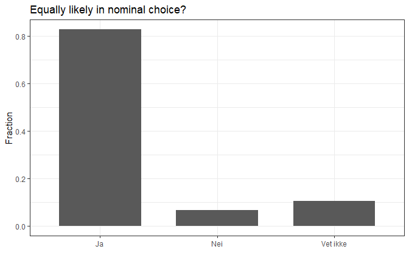

```r
df_k %>% filter(treatmentgroup=="Nominal Choice") %>%
  ggplot(aes(x=understanding1, y = (..count..)/tapply(..count..,..PANEL..,sum)[..PANEL..])) +
  geom_bar(width=0.7) + theme_bw() +
  labs(title= "Equally likely in nominal choice?",
                                x="", y = "Fraction")
```

Did those who didn’t understand distribute any differently than others?

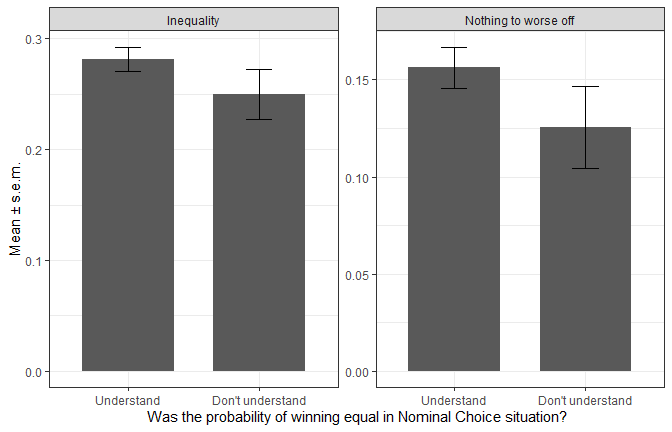

```r
u1 <- df_k %>% filter(treatmentgroup == "Nominal Choice") %>%
  dplyr::select(understanding1, inequality, zero_to_worst_off) %>%
  gather(inequality, zero_to_worst_off, key="outcome", value="y") %>%
  mutate(understand = fct_recode(understanding1,
                                 "Understand" = "Ja",
                                 "Don't understand" = "Nei",
                                 "Don't understand" = "Vet ikke")) %>%
  group_by(understand, outcome)
u1 %>%
  summarize(mean_y = mean(y, na.rm=TRUE), se_y = sd(y, na.rm=TRUE)/sqrt(n())) %>%
  mutate(outcome = fct_recode(outcome,
                              "Inequality" = "inequality",
                              "Nothing to worse off" = "zero_to_worst_off")) %>%
  ggplot(aes(x=understand, y=mean_y)) + geom_bar(stat="identity", width=0.7) +
    geom_errorbar(aes(ymax=mean_y+se_y, ymin=mean_y-se_y), width=0.2) +
  facet_wrap(~outcome, scales="free") +
  xlab("Was the probability of winning equal in Nominal Choice situation?") +
  ylab("Mean \u00B1 s.e.m.") + theme_bw()
```

Are these differences significant?

```r
u1 %>% filter(outcome=="inequality") %>% t.test(y ~ understand, data=.)
```

```
#>
#>  Welch Two Sample t-test
#>
#> data:  y by understand
#> t = 1.2594, df = 368.39, p-value = 0.2087
#> alternative hypothesis: true difference in means between group Understand and group Don't understand is not equal to 0
#> 95 percent confidence interval:
#>  -0.01775029  0.08098558
#> sample estimates:
#>       mean in group Understand mean in group Don't understand
#>                      0.2816176                      0.2500000
```

```r
u1 %>% filter(outcome=="inequality") %>% wilcox.test(y ~ understand, data=.)
```

```
#>
#>  Wilcoxon rank sum test with continuity correction
#>
#> data:  y by understand
#> W = 152685, p-value = 0.2824
#> alternative hypothesis: true location shift is not equal to 0
```

```r
u1z <- u1 %>% filter(outcome=="zero_to_worst_off") %>%
  group_by(understand, y) %>%
  summarize(n=n()) %>%
  spread(key=understand, value=n) %>%
  dplyr::select(-y)
prop.test(as.matrix(u1z))
```

```
#>
#>  2-sample test for equality of proportions with continuity correction
#>
#> data:  as.matrix(u1z)
#> X-squared = 1.2825, df = 1, p-value = 0.2574
#> alternative hypothesis: two.sided
#> 95 percent confidence interval:
#>  -0.08815484  0.01977077
#> sample estimates:
#>    prop 1    prop 2
#> 0.8229508 0.8571429
```

## Control over earnings before distribution choice

We asked whether the two participants had any control over their own earnings before the DM made their choices.

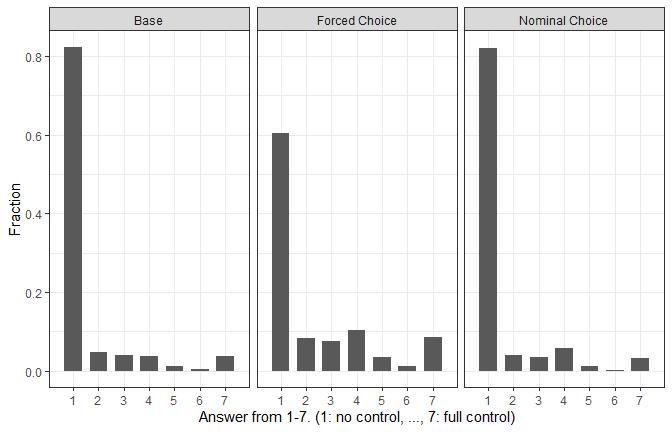

```r
df_k %>% filter(!is.na(understanding2n)) %>%
  ggplot(aes(x=understanding2n, y = (..count..)/tapply(..count..,..PANEL..,sum)[..PANEL..])) +
  geom_bar(width=0.7) +
  facet_wrap(~treatmentgroup) + theme_bw() +
  labs(x="Answer from 1-7. (1: no control, ..., 7: full control)", y = "Fraction") +
  scale_x_discrete(limits=c(1,2,3,4,5,6,7))
```

```r
ggsave(here("graphs", "control_earnings.pdf"))
```

What are the exact shares at “no control”?

```r
df_k %>% group_by(treatmentgroup) %>%
  summarize(share_no_control = mean( (understanding2n==1), na.rm=TRUE),
                                           n = n()) %>% knitr::kable(digits=3)
```

| treatmentgroup | share_no_control | n |
| --- | --- | --- |
| Base | 0.823 | 1456 |
| Forced Choice | 0.603 | 2864 |
| Nominal Choice | 0.819 | 1437 |

Are these differences significant?

```r
c1 <- df_k %>%  group_by(treatmentgroup) %>% summarize( no_control = sum(inequality == 1), n=n())
prop.test(c1$no_control, c1$n)
```

```
#>
#>  3-sample test for equality of proportions without continuity correction
#>
#> data:  c1$no_control out of c1$n
#> X-squared = 98.682, df = 2, p-value < 2.2e-16
#> alternative hypothesis: two.sided
#> sample estimates:
#>     prop 1     prop 2     prop 3
#> 0.08379121 0.20006983 0.15100905
```

```r
df_k %>% group_by(treatmentgroup) %>%
  summarize(share_no_control = mean( (understanding2n==1), na.rm=TRUE),
                                           n = n()) %>% knitr::kable(digits=3)
```

| treatmentgroup | share_no_control | n |
| --- | --- | --- |
| Base | 0.823 | 1456 |
| Forced Choice | 0.603 | 2864 |
| Nominal Choice | 0.819 | 1437 |

### Mediation …

Can we explain understanding with treatmentgroup? And does understanding knock out the treatment efects?

```r
dfmainu2 <- df_k %>% filter(!is.na(understanding2n))
ru2_1 <- dfmainu2 %>% lm(understanding2n ~ treatmentgroup + leftp + female + age_h + crt_h +
                           university + high_income , data=.)
ru2_2 <- dfmainu2 %>% lm(inequality ~ treatmentgroup + leftp + female + age_h + crt_h +
                           university + high_income, data=.)
ru2_3 <- dfmainu2 %>% lm(inequality ~ treatmentgroup + understanding2n  + leftp +
                           female + age_h + crt_h + university + high_income, data=.)
ru2_4 <- dfmainu2 %>% lm(inequality ~ treatmentgroup + factor(understanding2n) +
                           leftp + female + age_h + crt_h + university + high_income, data=.)
ru2_5 <- dfmainu2 %>% lm(zero_to_worst_off ~ treatmentgroup +  leftp +
                           female + age_h + crt_h + university + high_income, data=.)
ru2_6 <- dfmainu2 %>% lm(zero_to_worst_off ~ treatmentgroup + understanding2n +
                           leftp + female + age_h + crt_h + university + high_income, data=.)
ru2_7 <- dfmainu2 %>% lm(zero_to_worst_off ~ treatmentgroup + factor(understanding2n) +
                           leftp + female + age_h + crt_h + university + high_income,  data=.)

stargazer( ru2_1, ru2_2, ru2_3, ru2_4, ru2_5, ru2_6, ru2_7,
           se = list( sqrt(diag(cluster.vcov(ru2_1, cluster=1:length(ru2_1$residuals)))),
                      sqrt(diag(cluster.vcov(ru2_2, cluster=1:length(ru2_2$residuals)))),
                      sqrt(diag(cluster.vcov(ru2_3, cluster=1:length(ru2_3$residuals)))),
                      sqrt(diag(cluster.vcov(ru2_4, cluster=1:length(ru2_4$residuals)))),
                      sqrt(diag(cluster.vcov(ru2_5, cluster=1:length(ru2_5$residuals)))),
                      sqrt(diag(cluster.vcov(ru2_6, cluster=1:length(ru2_6$residuals)))),
                      sqrt(diag(cluster.vcov(ru2_7, cluster=1:length(ru2_7$residuals))))),
           type="text", style="aer", df=FALSE, keep.stat=c("rsq","n"),
           star.char=c("", "",""), notes="", notes.append=FALSE, report="vcsp", header=FALSE)
```

```
#>
#> ========================================================================================================
#>                              understanding2n          inequality                 zero_to_worst_off
#>                                    (1)          (2)       (3)       (4)       (5)       (6)       (7)
#> --------------------------------------------------------------------------------------------------------
#> treatmentgroupForced Choice       0.724        0.150     0.131     0.132     0.119     0.103     0.106
#>                                  (0.052)      (0.011)   (0.011)   (0.012)   (0.011)   (0.011)   (0.011)
#>                                 p = 0.000    p = 0.000 p = 0.000 p = 0.000 p = 0.000 p = 0.000 p = 0.000
#>
#> treatmentgroupNominal Choice      0.019        0.114     0.114     0.114     0.072     0.072     0.072
#>                                  (0.052)      (0.013)   (0.013)   (0.013)   (0.012)   (0.012)   (0.012)
#>                                 p = 0.716    p = 0.000 p = 0.000 p = 0.000 p = 0.000 p = 0.000 p = 0.000
#>
#> understanding2n                                          0.027                         0.021
#>                                                         (0.003)                       (0.003)
#>                                                        p = 0.000                     p = 0.000
#>
#> factor(understanding2n)2                                          -0.002                        -0.036
#>                                                                   (0.020)                       (0.019)
#>                                                                  p = 0.909                     p = 0.059
#>
#> factor(understanding2n)3                                           0.028                        -0.003
#>                                                                   (0.021)                       (0.021)
#>                                                                  p = 0.194                     p = 0.900
#>
#> factor(understanding2n)4                                           0.061                         0.046
#>                                                                   (0.021)                       (0.021)
#>                                                                  p = 0.004                     p = 0.026
#>
#> factor(understanding2n)5                                           0.124                         0.103
#>                                                                   (0.037)                       (0.039)
#>                                                                  p = 0.001                     p = 0.009
#>
#> factor(understanding2n)6                                           0.280                         0.217
#>                                                                   (0.062)                       (0.072)
#>                                                                  p = 0.000                     p = 0.003
#>
#> factor(understanding2n)7                                           0.157                         0.130
#>                                                                   (0.024)                       (0.025)
#>                                                                  p = 0.000                     p = 0.000
```

[output cut: 18 more lines]

```
#>                                  (0.047)      (0.010)   (0.010)   (0.010)   (0.010)   (0.010)   (0.010)
#>                                 p = 0.085    p = 0.062 p = 0.095 p = 0.092 p = 0.021 p = 0.032 p = 0.029
#>
#> high_income                       0.051        0.048     0.047     0.046     0.049     0.048     0.047
#>                                  (0.050)      (0.011)   (0.011)   (0.011)   (0.011)   (0.011)   (0.011)
#>                                 p = 0.309    p = 0.000 p = 0.000 p = 0.000 p = 0.000 p = 0.000 p = 0.000
#>
#> Constant                          1.821        0.231     0.182     0.212     0.107     0.067     0.094
#>                                  (0.070)      (0.016)   (0.017)   (0.016)   (0.015)   (0.016)   (0.015)
#>                                 p = 0.000    p = 0.000 p = 0.000 p = 0.000 p = 0.000 p = 0.000 p = 0.000
#>
#> Observations                      5,503        5,503     5,503     5,503     5,503     5,503     5,503
#> R2                                0.066        0.077     0.091     0.093     0.049     0.058     0.061
#> --------------------------------------------------------------------------------------------------------
#> Notes:
```

Also to latex (silent):

We see that treatment does have a sizable effect on understanding, but that the effects of choice remains strong even when controlling for the level of understanding. This does not depend on how the understanding is added linearly (as seen by comparing column 3 vs 4, and 6 vs 7).

We see that the total number of observations is lower than in the main regressions. This is because some respondents chose the “don’t know” option, and these don’t enter the regressions (or the graph above). The proportion that choice the “don’t know” option was not much different by treatment:

```r
df_k %>% group_by(treatment) %>% summarize(share_dont_know = mean(understanding2=="Vet ikke")) %>%
  knitr::kable(digits=3)
```

| treatment | share_dont_know |
| --- | --- |
| Base (w) | 0.052 |
| Forced Choice (w) | 0.042 |
| Nominal Choice (w) | 0.034 |
| Base (nw) | 0.051 |
| Forced Choice (nw) | 0.046 |
| Nominal Choice (nw) | 0.044 |

### Restricting to those that were not confused

Can we still find the main treatmentgroup if we exclude all those who are in doubt about the workers not having control? Let’s re-estimate the main table for the representative sample on the subset of people who are absoluteley sure.

```r
df_c <- df_k %>% filter(understanding2n==1)

cineq_1 <-  df_c %>% lm(inequality ~ treatmentgroup , data = . )
cineq_2 <-  df_c %>% lm(inequality ~ treatmentgroup  +
                             leftp + female + age_h + crt_h, data=.)
cineq_3 <-  df_c %>% lm(inequality ~ treatmentgroup  +
                             leftp + female + age_h + crt_h +
                             university + high_income, data=.)

cnoth_1 <-  df_c %>% lm( zero_to_worst_off ~ treatmentgroup  , data = . )
cnoth_2  <- df_c %>% lm( zero_to_worst_off ~ treatmentgroup +
                              leftp + female + age_h + crt_h, data=.)
cnoth_3  <- df_c %>% lm( zero_to_worst_off ~ treatmentgroup +
                              leftp + female + age_h + crt_h +
                              university + high_income, data=.)
```

Now, outputting these regressions to a table.

```r
stargazer(cineq_1, cineq_2, cineq_3, cnoth_1, cnoth_2, cnoth_3,
          se = list(sqrt(diag(cluster.vcov(cineq_1, cluster=1:nrow(df_c)))),
                    sqrt(diag(cluster.vcov(cineq_2, cluster=1:nrow(df_c)))),
                    sqrt(diag(cluster.vcov(cineq_3, cluster=1:nrow(df_c)))),
                    sqrt(diag(cluster.vcov(cnoth_1, cluster=1:nrow(df_c)))),
                    sqrt(diag(cluster.vcov(cnoth_2, cluster=1:nrow(df_c)))),
                    sqrt(diag(cluster.vcov(cnoth_3, cluster=1:nrow(df_c))))),
         type="text", style="aer", df=FALSE, keep.stat=c("rsq","n"),
         p.auto=TRUE,
         star.char=c("", "",""), notes="", notes.append=FALSE, report="vcsp")
```

```
#>
#> ========================================================================================
#>                                       inequality                 zero_to_worst_off
#>                                 (1)       (2)       (3)       (4)       (5)       (6)
#> ----------------------------------------------------------------------------------------
#> treatmentgroupForced Choice    0.129     0.131     0.130     0.093     0.095     0.094
#>                               (0.013)   (0.013)   (0.013)   (0.012)   (0.012)   (0.012)
#>                              p = 0.000 p = 0.000 p = 0.000 p = 0.000 p = 0.000 p = 0.000
#>
#> treatmentgroupNominal Choice   0.117     0.115     0.114     0.071     0.070     0.070
#>                               (0.014)   (0.014)   (0.014)   (0.013)   (0.013)   (0.013)
#>                              p = 0.000 p = 0.000 p = 0.000 p = 0.000 p = 0.000 p = 0.000
#>
#> leftp                                   -0.067    -0.063              -0.049    -0.045
#>                                         (0.013)   (0.013)             (0.012)   (0.012)
#>                                        p = 0.000 p = 0.000           p = 0.000 p = 0.001
#>
#> female                                  -0.087    -0.075              -0.049    -0.038
#>                                         (0.012)   (0.012)             (0.011)   (0.011)
#>                                        p = 0.000 p = 0.000           p = 0.000 p = 0.001
#>
#> age_h                                   -0.049    -0.048              -0.031    -0.031
#>                                         (0.012)   (0.011)             (0.011)   (0.011)
#>                                        p = 0.000 p = 0.000           p = 0.005 p = 0.005
#>
#> crt_h                                    0.059     0.054               0.051     0.045
#>                                         (0.012)   (0.012)             (0.011)   (0.011)
#>                                        p = 0.000 p = 0.000           p = 0.000 p = 0.000
#>
#> university                                         0.008                         0.016
#>                                                   (0.012)                       (0.011)
#>                                                  p = 0.501                     p = 0.151
#>
#> high_income                                        0.056                         0.055
#>                                                   (0.013)                       (0.013)
#>                                                  p = 0.000                     p = 0.000
#>
#> Constant                       0.154     0.237     0.207     0.081     0.129     0.095
#>                               (0.009)   (0.017)   (0.018)   (0.008)   (0.015)   (0.017)
#>                              p = 0.000 p = 0.000 p = 0.000 p = 0.000 p = 0.000 p = 0.000
#>
#> Observations                   3,922     3,922     3,922     3,922     3,922     3,922
#> R2                             0.023     0.062     0.067     0.013     0.033     0.040
#> ----------------------------------------------------------------------------------------
#> Notes:
```

Also to latex (silent):

# Balance table (appendix)

```r
dfk_summary <- df_k %>% group_by(treatment) %>% summarize(mean_age = mean(age), se_age = sd(age)/sqrt(n()),
                                                          mean_female = mean(female), se_female=sd(female)/sqrt(n()),
                                                          mean_crt = mean(crt), se_crt = sd(crt)/sqrt(n()),
                                                          mean_left = mean(leftp), se_leftp=sd(leftp)/sqrt(n()),
                                                          n= n())
dfk_totals <- df_k %>% summarize(mean_age = mean(age), se_age = sd(age)/sqrt(n()),
                                 mean_female = mean(female), se_female=sd(female)/sqrt(n()),
                                 mean_crt = mean(crt), se_crt = sd(crt)/sqrt(n()),
                                 mean_left = mean(leftp), se_leftp=sd(leftp)/sqrt(n()),
                                 n= n())
```

Output of balance table

```r
dfk_summary %>% knitr::kable(digits=c(3,1,2,2,2,2,2,2,2,0))
```

| treatment | mean_age | se_age | mean_female | se_female | mean_crt | se_crt | mean_left | se_leftp | n |
| --- | --- | --- | --- | --- | --- | --- | --- | --- | --- |
| Base (w) | 49.7 | 0.62 | 0.49 | 0.02 | 1.33 | 0.04 | 0.69 | 0.02 | 745 |
| Forced Choice (w) | 48.0 | 0.37 | 0.46 | 0.01 | 1.37 | 0.02 | 0.69 | 0.01 | 2123 |
| Nominal Choice (w) | 48.6 | 0.63 | 0.44 | 0.02 | 1.40 | 0.04 | 0.67 | 0.02 | 713 |
| Base (nw) | 48.2 | 0.63 | 0.51 | 0.02 | 1.38 | 0.04 | 0.69 | 0.02 | 711 |
| Forced Choice (nw) | 48.1 | 0.62 | 0.46 | 0.02 | 1.40 | 0.04 | 0.70 | 0.02 | 741 |
| Nominal Choice (nw) | 49.2 | 0.63 | 0.51 | 0.02 | 1.35 | 0.04 | 0.70 | 0.02 | 724 |

```r
dfk_totals %>% knitr::kable(digits=c(1,2,2,2,2,2,2,2,0))
```

| mean_age | se_age | mean_female | se_female | mean_crt | se_crt | mean_left | se_leftp | n |
| --- | --- | --- | --- | --- | --- | --- | --- | --- |
| 48.5 | 0.22 | 0.48 | 0.01 | 1.37 | 0.02 | 0.69 | 0.01 | 5757 |

## Balance tests

```r
df_k %>% lm(age ~ treatment_org, data=.) %>% summary()
```

```
#>
#> Call:
#> lm(formula = age ~ treatment_org, data = .)
#>
#> Residuals:
#>     Min      1Q  Median      3Q     Max
#> -31.720 -15.163   0.837  14.280  40.991
#>
#> Coefficients:
#>                                        Estimate Std. Error t value Pr(>|t|)
#> (Intercept)                             49.7201     0.6185  80.395   <2e-16 ***
#> treatment_orgForced Choice (w)          -0.8341     0.8879  -0.939   0.3476
#> treatment_orgNominal Choice (w)         -1.1121     0.8844  -1.258   0.2086
#> treatment_orgBase (nw)                  -1.5570     0.8850  -1.759   0.0786 .
#> treatment_orgForced Choice (nw)         -1.6304     0.8758  -1.862   0.0627 .
#> treatment_orgNominal Choice (nw)        -0.5578     0.8809  -0.633   0.5266
#> treatment_orgForced Choice strong       -2.0614     0.8828  -2.335   0.0196 *
#> treatment_orgForced Choice very strong  -2.2109     0.8876  -2.491   0.0128 *
#> ---
#> Signif. codes:  0 '***' 0.001 '**' 0.01 '*' 0.05 '.' 0.1 ' ' 1
#>
#> Residual standard error: 16.88 on 5749 degrees of freedom
#> Multiple R-squared:  0.001792,   Adjusted R-squared:  0.0005768
#> F-statistic: 1.475 on 7 and 5749 DF,  p-value: 0.1713
```

```r
df_k %>% lm(female ~ treatment_org, data=.) %>% summary()
```

```
#>
#> Call:
#> lm(formula = female ~ treatment_org, data = .)
#>
#> Residuals:
#>     Min      1Q  Median      3Q     Max
#> -0.5097 -0.4708 -0.4446  0.5292  0.5554
#>
#> Coefficients:
#>                                        Estimate Std. Error t value Pr(>|t|)
#> (Intercept)                             0.48859    0.01829  26.713   <2e-16 ***
#> treatment_orgForced Choice (w)         -0.02848    0.02626  -1.084   0.2782
#> treatment_orgNominal Choice (w)        -0.04399    0.02615  -1.682   0.0926 .
#> treatment_orgBase (nw)                  0.02055    0.02617   0.785   0.4324
#> treatment_orgForced Choice (nw)        -0.02840    0.02590  -1.097   0.2729
#> treatment_orgNominal Choice (nw)        0.02108    0.02605   0.809   0.4185
#> treatment_orgForced Choice strong      -0.02898    0.02611  -1.110   0.2670
#> treatment_orgForced Choice very strong -0.01775    0.02625  -0.676   0.4989
#> ---
#> Signif. codes:  0 '***' 0.001 '**' 0.01 '*' 0.05 '.' 0.1 ' ' 1
#>
#> Residual standard error: 0.4992 on 5749 degrees of freedom
#> Multiple R-squared:  0.002086,   Adjusted R-squared:  0.0008708
#> F-statistic: 1.717 on 7 and 5749 DF,  p-value: 0.1003
```

```r
df_k %>% lm(crt ~ treatment_org, data=.) %>% summary()
```

```
#>
#> Call:
#> lm(formula = crt ~ treatment_org, data = .)
#>
#> Residuals:
#>     Min      1Q  Median      3Q     Max
#> -1.4259 -1.3454 -0.3454  0.6658  1.6658
#>
#> Coefficients:
#>                                        Estimate Std. Error t value Pr(>|t|)
#> (Intercept)                             1.33423    0.04188  31.856   <2e-16 ***
#> treatment_orgForced Choice (w)          0.09170    0.06013   1.525    0.127
#> treatment_orgNominal Choice (w)         0.06409    0.05989   1.070    0.285
#> treatment_orgBase (nw)                  0.04974    0.05994   0.830    0.407
#> treatment_orgForced Choice (nw)         0.06928    0.05931   1.168    0.243
#> treatment_orgNominal Choice (nw)        0.01522    0.05966   0.255    0.799
#> treatment_orgForced Choice strong       0.01118    0.05979   0.187    0.852
#> treatment_orgForced Choice very strong  0.01428    0.06011   0.238    0.812
#> ---
#> Signif. codes:  0 '***' 0.001 '**' 0.01 '*' 0.05 '.' 0.1 ' ' 1
#>
#> Residual standard error: 1.143 on 5749 degrees of freedom
#> Multiple R-squared:  0.0007564,  Adjusted R-squared:  -0.0004603
#> F-statistic: 0.6217 on 7 and 5749 DF,  p-value: 0.7384
```

```r
df_k %>% lm(leftp ~ treatment_org, data=.) %>% summary()
```

```
#>
#> Call:
#> lm(formula = leftp ~ treatment_org, data = .)
#>
#> Residuals:
#>     Min      1Q  Median      3Q     Max
#> -0.7103 -0.6823  0.2983  0.3144  0.3254
#>
#> Coefficients:
#>                                          Estimate Std. Error t value Pr(>|t|)
#> (Intercept)                             0.6859060  0.0169281  40.519   <2e-16
#> treatment_orgForced Choice (w)         -0.0035699  0.0243037  -0.147    0.883
#> treatment_orgNominal Choice (w)        -0.0112917  0.0242070  -0.466    0.641
#> treatment_orgBase (nw)                  0.0004512  0.0242244   0.019    0.985
#> treatment_orgForced Choice (nw)         0.0185474  0.0239722   0.774    0.439
#> treatment_orgNominal Choice (nw)        0.0157514  0.0241129   0.653    0.514
#> treatment_orgForced Choice strong       0.0244004  0.0241639   1.010    0.313
#> treatment_orgForced Choice very strong -0.0002730  0.0242948  -0.011    0.991
#>
#> (Intercept)                            ***
#> treatment_orgForced Choice (w)
#> treatment_orgNominal Choice (w)
#> treatment_orgBase (nw)
#> treatment_orgForced Choice (nw)
#> treatment_orgNominal Choice (nw)
#> treatment_orgForced Choice strong
#> treatment_orgForced Choice very strong
#> ---
#> Signif. codes:  0 '***' 0.001 '**' 0.01 '*' 0.05 '.' 0.1 ' ' 1
#>
#> Residual standard error: 0.462 on 5749 degrees of freedom
#> Multiple R-squared:  0.0006364,  Adjusted R-squared:  -0.0005805
#> F-statistic: 0.523 on 7 and 5749 DF,  p-value: 0.8179
```